# Project: Identify Customer Segments

In this project, you will apply unsupervised learning techniques to identify segments of the population that form the core customer base for a mail-order sales company in Germany. These segments can then be used to direct marketing campaigns towards audiences that will have the highest expected rate of returns. The data that you will use has been provided by our partners at Bertelsmann Arvato Analytics, and represents a real-life data science task.

This notebook will help you complete this task by providing a framework within which you will perform your analysis steps. In each step of the project, you will see some text describing the subtask that you will perform, followed by one or more code cells for you to complete your work. **Feel free to add additional code and markdown cells as you go along so that you can explore everything in precise chunks.** The code cells provided in the base template will outline only the major tasks, and will usually not be enough to cover all of the minor tasks that comprise it.

It should be noted that while there will be precise guidelines on how you should handle certain tasks in the project, there will also be places where an exact specification is not provided. **There will be times in the project where you will need to make and justify your own decisions on how to treat the data.** These are places where there may not be only one way to handle the data. In real-life tasks, there may be many valid ways to approach an analysis task. One of the most important things you can do is clearly document your approach so that other scientists can understand the decisions you've made.

At the end of most sections, there will be a Markdown cell labeled **Discussion**. In these cells, you will report your findings for the completed section, as well as document the decisions that you made in your approach to each subtask. **Your project will be evaluated not just on the code used to complete the tasks outlined, but also your communication about your observations and conclusions at each stage.**

**Author:** Stefan Grandl (August 2023)

**Disclaimer:**

For the solution of this project I took inspiration from these sources:

- https://katba-caroline.com/wp-content/uploads/2018/12/Identify_Customer_Segments-1.html
- https://ksatola.github.io/projects/Identify_Customer_Segments10new_final.html

Furthermore, I used ChatGPT as a code assistant. I didn't use it for intellectual parts throughout the project, but rather gave it concrete prompts to design code parts, when I already had an explicit vision in mind. This gave me a more professional code, especially with respect to type hinting, docstrings, comments and Pythonic coding.

IMPORTANT NOTE: I didn't give any data to ChatGPT, I always anonymised my questions and used dummy data!

```python
# import libraries here; add more as necessary
import numpy as np
import pandas as pd
import matplotlib.pyplot as plt
from matplotlib.ticker import PercentFormatter
import seaborn as sns
from typing import Dict, List, Tuple
import random
from scipy.stats import ks_2samp
from tqdm import tqdm
from sklearn.decomposition import PCA
from sklearn.preprocessing import StandardScaler, Imputer

# magic word for producing visualizations in notebook
%matplotlib inline

'''
Import note: The classroom currently uses sklearn version 0.19.
If you need to use an imputer, it is available in sklearn.preprocessing.Imputer,
instead of sklearn.impute as in newer versions of sklearn.
'''
```

```
'\nImport note: The classroom currently uses sklearn version 0.19.\nIf you need to use an imputer, it is available in sklearn.preprocessing.Imputer,\ninstead of sklearn.impute as in newer versions of sklearn.\n'
```

### Step 0: Load the Data

Each row of the demographics files represents a single person, but also includes information outside of individuals, including information about their household, building, and neighborhood. You will use this information to cluster the general population into groups with similar demographic properties. Then, you will see how the people in the customers dataset fit into those created clusters. The hope here is that certain clusters are over-represented in the customers data, as compared to the general population; those over-represented clusters will be assumed to be part of the core userbase. This information can then be used for further applications, such as targeting for a marketing campaign.

To start off with, load in the demographics data for the general population into a pandas DataFrame, and do the same for the feature attributes summary. Note for all of the `.csv` data files in this project: they're semicolon (`;`) delimited, so you'll need an additional argument in your [`read_csv()`](https://pandas.pydata.org/pandas-docs/stable/generated/pandas.read_csv.html) call to read in the data properly. Also, considering the size of the main dataset, it may take some time for it to load completely.

Once the dataset is loaded, it's recommended that you take a little bit of time just browsing the general structure of the dataset and feature summary file. You'll be getting deep into the innards of the cleaning in the first major step of the project, so gaining some general familiarity can help you get your bearings.

```python
# Load in the general demographics data.
azdias = pd.read_csv('Udacity_AZDIAS_Subset.csv', sep=';')

# Load in the feature summary file.
feat_info = pd.read_csv('AZDIAS_Feature_Summary.csv', sep=';')
```

```python
# just a copy for reuse if something gets messed up later :)
#azdias2 = azdias
```

```python
pd.options.display.max_columns=20 # default: 20
pd.options.display.max_rows=20 # default: 60
```

```python
# Check the structure of the data after it's loaded (e.g. print the number of
# rows and columns, print the first few rows).
azdias.head(20).transpose()
```

|  | 0 | 1 | 2 | 3 | 4 | 5 | 6 | 7 | 8 | 9 | 10 | 11 | 12 | 13 | 14 | 15 | 16 | 17 | 18 | 19 |
| --- | --- | --- | --- | --- | --- | --- | --- | --- | --- | --- | --- | --- | --- | --- | --- | --- | --- | --- | --- | --- |
| AGER_TYP | -1 | -1 | -1 | 2 | -1 | 3 | -1 | -1 | -1 | -1 | 0 | -1 | -1 | -1 | -1 | 1 | -1 | -1 | -1 | -1 |
| ALTERSKATEGORIE_GROB | 2 | 1 | 3 | 4 | 3 | 1 | 2 | 1 | 3 | 3 | 3 | 2 | 3 | 1 | 3 | 4 | 1 | 2 | 2 | 3 |
| ANREDE_KZ | 1 | 2 | 2 | 2 | 1 | 2 | 2 | 1 | 1 | 2 | 2 | 1 | 1 | 2 | 1 | 2 | 2 | 1 | 2 | 1 |
| CJT_GESAMTTYP | 2 | 5 | 3 | 2 | 5 | 2 | 5 | 3 | 3 | 4 | 1 | 6 | 6 | 5 | 6 | 4 | 1 | 6 | 6 | 3 |
| FINANZ_MINIMALIST | 3 | 1 | 1 | 4 | 4 | 3 | 1 | 3 | 4 | 2 | 2 | 3 | 5 | 1 | 3 | 4 | 4 | 3 | 2 | 5 |
| FINANZ_SPARER | 4 | 5 | 4 | 2 | 3 | 1 | 5 | 3 | 4 | 4 | 2 | 4 | 3 | 4 | 4 | 1 | 3 | 4 | 4 | 2 |
| FINANZ_VORSORGER | 3 | 2 | 1 | 5 | 4 | 5 | 1 | 4 | 2 | 2 | 5 | 3 | 4 | 3 | 3 | 5 | 1 | 3 | 1 | 3 |
| FINANZ_ANLEGER | 5 | 5 | 2 | 2 | 1 | 2 | 5 | 1 | 4 | 3 | 3 | 5 | 2 | 5 | 5 | 1 | 4 | 5 | 5 | 1 |
| FINANZ_UNAUFFAELLIGER | 5 | 4 | 3 | 1 | 3 | 2 | 4 | 3 | 2 | 5 | 1 | 5 | 4 | 5 | 5 | 1 | 5 | 5 | 4 | 3 |
| FINANZ_HAUSBAUER | 3 | 5 | 5 | 2 | 2 | 5 | 3 | 2 | 2 | 4 | 5 | 3 | 1 | 2 | 3 | 4 | 1 | 3 | 1 | 1 |
| ... | ... | ... | ... | ... | ... | ... | ... | ... | ... | ... | ... | ... | ... | ... | ... | ... | ... | ... | ... | ... |
| PLZ8_ANTG1 | NaN | 2 | 3 | 2 | 2 | 2 | 3 | 3 | 2 | 2 | 2 | NaN | 3 | 2 | NaN | NaN | 3 | NaN | 2 | 2 |
| PLZ8_ANTG2 | NaN | 3 | 3 | 2 | 4 | 3 | 3 | 3 | 3 | 3 | 4 | NaN | 3 | 1 | NaN | NaN | 3 | NaN | 3 | 4 |
| PLZ8_ANTG3 | NaN | 2 | 1 | 2 | 2 | 1 | 1 | 1 | 2 | 2 | 2 | NaN | 1 | 1 | NaN | NaN | 1 | NaN | 2 | 2 |
| PLZ8_ANTG4 | NaN | 1 | 0 | 0 | 1 | 1 | 0 | 0 | 1 | 1 | 0 | NaN | 0 | 1 | NaN | NaN | 0 | NaN | 1 | 1 |
| PLZ8_BAUMAX | NaN | 1 | 1 | 1 | 2 | 1 | 1 | 1 | 1 | 1 | 2 | NaN | 1 | 1 | NaN | NaN | 1 | NaN | 1 | 2 |
| PLZ8_HHZ | NaN | 5 | 4 | 3 | 3 | 5 | 5 | 4 | 3 | 3 | 3 | NaN | 5 | 3 | NaN | NaN | 3 | NaN | 3 | 5 |
| PLZ8_GBZ | NaN | 4 | 4 | 4 | 3 | 5 | 5 | 4 | 3 | 3 | 3 | NaN | 5 | 3 | NaN | NaN | 4 | NaN | 3 | 4 |
| ARBEIT | NaN | 3 | 3 | 2 | 4 | 2 | 4 | 2 | 2 | 2 | 4 | NaN | 3 | 3 | NaN | 4 | 1 | NaN | 3 | 4 |
| ORTSGR_KLS9 | NaN | 5 | 5 | 3 | 6 | 3 | 6 | 5 | 4 | 3 | 6 | NaN | 6 | 6 | NaN | 8 | 2 | NaN | 4 | 6 |
| RELAT_AB | NaN | 4 | 2 | 3 | 5 | 3 | 3 | 2 | 3 | 1 | 5 | NaN | 4 | 4 | NaN | 5 | 1 | NaN | 3 | 3 |

85 rows × 20 columns

```python
azdias.describe().transpose()
```

|  | count | mean | std | min | 25% | 50% | 75% | max |
| --- | --- | --- | --- | --- | --- | --- | --- | --- |
| AGER_TYP | 891221.0 | -0.358435 | 1.198724 | -1.0 | -1.0 | -1.0 | -1.0 | 3.0 |
| ALTERSKATEGORIE_GROB | 891221.0 | 2.777398 | 1.068775 | 1.0 | 2.0 | 3.0 | 4.0 | 9.0 |
| ANREDE_KZ | 891221.0 | 1.522098 | 0.499512 | 1.0 | 1.0 | 2.0 | 2.0 | 2.0 |
| CJT_GESAMTTYP | 886367.0 | 3.632838 | 1.595021 | 1.0 | 2.0 | 4.0 | 5.0 | 6.0 |
| FINANZ_MINIMALIST | 891221.0 | 3.074528 | 1.321055 | 1.0 | 2.0 | 3.0 | 4.0 | 5.0 |
| FINANZ_SPARER | 891221.0 | 2.821039 | 1.464749 | 1.0 | 1.0 | 3.0 | 4.0 | 5.0 |
| FINANZ_VORSORGER | 891221.0 | 3.401106 | 1.322134 | 1.0 | 3.0 | 3.0 | 5.0 | 5.0 |
| FINANZ_ANLEGER | 891221.0 | 3.033328 | 1.529603 | 1.0 | 2.0 | 3.0 | 5.0 | 5.0 |
| FINANZ_UNAUFFAELLIGER | 891221.0 | 2.874167 | 1.486731 | 1.0 | 2.0 | 3.0 | 4.0 | 5.0 |
| FINANZ_HAUSBAUER | 891221.0 | 3.075121 | 1.353248 | 1.0 | 2.0 | 3.0 | 4.0 | 5.0 |
| ... | ... | ... | ... | ... | ... | ... | ... | ... |
| PLZ8_ANTG1 | 774706.0 | 2.253330 | 0.972008 | 0.0 | 1.0 | 2.0 | 3.0 | 4.0 |
| PLZ8_ANTG2 | 774706.0 | 2.801858 | 0.920309 | 0.0 | 2.0 | 3.0 | 3.0 | 4.0 |
| PLZ8_ANTG3 | 774706.0 | 1.595426 | 0.986736 | 0.0 | 1.0 | 2.0 | 2.0 | 3.0 |
| PLZ8_ANTG4 | 774706.0 | 0.699166 | 0.727137 | 0.0 | 0.0 | 1.0 | 1.0 | 2.0 |
| PLZ8_BAUMAX | 774706.0 | 1.943913 | 1.459654 | 1.0 | 1.0 | 1.0 | 3.0 | 5.0 |
| PLZ8_HHZ | 774706.0 | 3.612821 | 0.973967 | 1.0 | 3.0 | 4.0 | 4.0 | 5.0 |
| PLZ8_GBZ | 774706.0 | 3.381087 | 1.111598 | 1.0 | 3.0 | 3.0 | 4.0 | 5.0 |
| ARBEIT | 794005.0 | 3.167854 | 1.002376 | 1.0 | 3.0 | 3.0 | 4.0 | 9.0 |
| ORTSGR_KLS9 | 794005.0 | 5.293002 | 2.303739 | 0.0 | 4.0 | 5.0 | 7.0 | 9.0 |
| RELAT_AB | 794005.0 | 3.072220 | 1.362980 | 1.0 | 2.0 | 3.0 | 4.0 | 9.0 |

81 rows × 8 columns

```python
azdias.info()
```

```
<class 'pandas.core.frame.DataFrame'>
RangeIndex: 891221 entries, 0 to 891220
Data columns (total 85 columns):
AGER_TYP                 891221 non-null int64
ALTERSKATEGORIE_GROB     891221 non-null int64
ANREDE_KZ                891221 non-null int64
CJT_GESAMTTYP            886367 non-null float64
FINANZ_MINIMALIST        891221 non-null int64
FINANZ_SPARER            891221 non-null int64
FINANZ_VORSORGER         891221 non-null int64
FINANZ_ANLEGER           891221 non-null int64
FINANZ_UNAUFFAELLIGER    891221 non-null int64
FINANZ_HAUSBAUER         891221 non-null int64
FINANZTYP                891221 non-null int64
GEBURTSJAHR              891221 non-null int64
GFK_URLAUBERTYP          886367 non-null float64
GREEN_AVANTGARDE         891221 non-null int64
HEALTH_TYP               891221 non-null int64
LP_LEBENSPHASE_FEIN      886367 non-null float64
LP_LEBENSPHASE_GROB      886367 non-null float64
LP_FAMILIE_FEIN          886367 non-null float64
LP_FAMILIE_GROB          886367 non-null float64
LP_STATUS_FEIN           886367 non-null float64
LP_STATUS_GROB           886367 non-null float64
NATIONALITAET_KZ         891221 non-null int64
PRAEGENDE_JUGENDJAHRE    891221 non-null int64
RETOURTYP_BK_S           886367 non-null float64
SEMIO_SOZ                891221 non-null int64
SEMIO_FAM                891221 non-null int64
SEMIO_REL                891221 non-null int64
SEMIO_MAT                891221 non-null int64
SEMIO_VERT               891221 non-null int64
SEMIO_LUST               891221 non-null int64
SEMIO_ERL                891221 non-null int64
SEMIO_KULT               891221 non-null int64
SEMIO_RAT                891221 non-null int64
SEMIO_KRIT               891221 non-null int64
SEMIO_DOM                891221 non-null int64
SEMIO_KAEM               891221 non-null int64
SEMIO_PFLICHT            891221 non-null int64
```

[output cut: 35 more lines]

```
ONLINE_AFFINITAET        886367 non-null float64
REGIOTYP                 770025 non-null float64
KBA13_ANZAHL_PKW         785421 non-null float64
PLZ8_ANTG1               774706 non-null float64
PLZ8_ANTG2               774706 non-null float64
PLZ8_ANTG3               774706 non-null float64
PLZ8_ANTG4               774706 non-null float64
PLZ8_BAUMAX              774706 non-null float64
PLZ8_HHZ                 774706 non-null float64
PLZ8_GBZ                 774706 non-null float64
ARBEIT                   794005 non-null float64
ORTSGR_KLS9              794005 non-null float64
RELAT_AB                 794005 non-null float64
dtypes: float64(49), int64(32), object(4)
memory usage: 578.0+ MB
```

```python
feat_info.head(10)
```

|  | attribute | information_level | type | missing_or_unknown |
| --- | --- | --- | --- | --- |
| 0 | AGER_TYP | person | categorical | [-1,0] |
| 1 | ALTERSKATEGORIE_GROB | person | ordinal | [-1,0,9] |
| 2 | ANREDE_KZ | person | categorical | [-1,0] |
| 3 | CJT_GESAMTTYP | person | categorical | [0] |
| 4 | FINANZ_MINIMALIST | person | ordinal | [-1] |
| 5 | FINANZ_SPARER | person | ordinal | [-1] |
| 6 | FINANZ_VORSORGER | person | ordinal | [-1] |
| 7 | FINANZ_ANLEGER | person | ordinal | [-1] |
| 8 | FINANZ_UNAUFFAELLIGER | person | ordinal | [-1] |
| 9 | FINANZ_HAUSBAUER | person | ordinal | [-1] |

```python
feat_info.describe()
```

|  | attribute | information_level | type | missing_or_unknown |
| --- | --- | --- | --- | --- |
| count | 85 | 85 | 85 | 85 |
| unique | 85 | 9 | 5 | 9 |
| top | KBA05_ANTG2 | person | ordinal | [-1] |
| freq | 1 | 43 | 49 | 26 |

```python
feat_info.info()
```

```
<class 'pandas.core.frame.DataFrame'>
RangeIndex: 85 entries, 0 to 84
Data columns (total 4 columns):
attribute             85 non-null object
information_level     85 non-null object
type                  85 non-null object
missing_or_unknown    85 non-null object
dtypes: object(4)
memory usage: 2.7+ KB
```

> **Tip**: Add additional cells to keep everything in reasonably-sized chunks! Keyboard shortcut `esc --> a` (press escape to enter command mode, then press the 'A' key) adds a new cell before the active cell, and `esc --> b` adds a new cell after the active cell. If you need to convert an active cell to a markdown cell, use `esc --> m` and to convert to a code cell, use `esc --> y`.

## Step 1: Preprocessing

### Step 1.1: Assess Missing Data

The feature summary file contains a summary of properties for each demographics data column. You will use this file to help you make cleaning decisions during this stage of the project. First of all, you should assess the demographics data in terms of missing data. Pay attention to the following points as you perform your analysis, and take notes on what you observe. Make sure that you fill in the **Discussion** cell with your findings and decisions at the end of each step that has one!

#### Step 1.1.1: Convert Missing Value Codes to NaNs

The fourth column of the feature attributes summary (loaded in above as `feat_info`) documents the codes from the data dictionary that indicate missing or unknown data. While the file encodes this as a list (e.g. `[-1,0]`), this will get read in as a string object. You'll need to do a little bit of parsing to make use of it to identify and clean the data. Convert data that matches a 'missing' or 'unknown' value code into a numpy NaN value. You might want to see how much data takes on a 'missing' or 'unknown' code, and how much data is naturally missing, as a point of interest.

**As one more reminder, you are encouraged to add additional cells to break up your analysis into manageable chunks.**

```python
# Identify missing or unknown data values and convert them to NaNs.
```

```python
n_missing_data = azdias.isnull().sum().sum()
print(f"Number of missing data points in 'azdias': {n_missing_data:,}")
```

```
Number of missing data points in 'azdias': 4,896,838
```

At first I want to see which entries occur in the column 'missing_or_unknown' in `feat_info`:

```python
unique_entries = feat_info['missing_or_unknown'].unique()
print(unique_entries)
```

```
['[-1,0]' '[-1,0,9]' '[0]' '[-1]' '[]' '[-1,9]' '[-1,X]' '[XX]' '[-1,XX]']
```

Obviously, missing or unknown values are given as '[]', 'X', 'XX' or positive or negative digits - so convert the digits to integers, and keep the rest untouched.

```python
def parse_missing_values(value: str) -> list:
    # Note: comments and docstring were created with the help of ChatGPT
    """
    Parse the string representation of missing values from the 'missing_or_unknown' column.

    The function converts the string representation of lists (e.g., '[-1,0]') to actual lists.
    Each entry in the list is converted to an integer if it represents a digit (or a negative digit).
    Otherwise, the entry is converted to a NaN value.

    Parameters:
        value (str): The string representation of missing values.

    Returns:
        list: A list containing integers and/or NaN values based on the input string.
    """

    # Return an empty list if the input value is an empty string
    if value == "":
        return []

    # Remove brackets and split by comma
    parsed = value.strip('[]').split(',')

    # Convert to appropriate data type based on the condition
    return [int(x) if x.lstrip('-').isdigit() else x for x in parsed]
```

Now, loop through all columns in `azdias`, parse the entries in the corresponding 'missing_or_unknown' column in `feat_info` and eventually replace the values in `azdias` with np.nan:

```python
for column_name in azdias.columns:
    # Get the corresponding missing or unknown values for the column
    missing_values = feat_info.loc[feat_info['attribute'] == column_name, 'missing_or_unknown'].iloc[0]
    #print(missing_values)
    parsed_missing_values = parse_missing_values(missing_values)

    # Replace missing or unknown values in the column with np.nan
    if parsed_missing_values:
        azdias[column_name].replace(parsed_missing_values, np.nan, inplace=True)
```

```python
n_missing_data_repl = azdias.isnull().sum().sum()
print(f"Number of missing data points in 'azdias' after replacement: {n_missing_data_repl:,}")
print(f"After replacement there are {n_missing_data_repl - n_missing_data:,} more data points marked as missing or unknown.")
```

```
Number of missing data points in 'azdias' after replacement: 8,373,929
After replacement there are 3,477,091 more data points marked as missing or unknown.
```

```python
azdias.head(20).T
```

|  | 0 | 1 | 2 | 3 | 4 | 5 | 6 | 7 | 8 | 9 | 10 | 11 | 12 | 13 | 14 | 15 | 16 | 17 | 18 | 19 |
| --- | --- | --- | --- | --- | --- | --- | --- | --- | --- | --- | --- | --- | --- | --- | --- | --- | --- | --- | --- | --- |
| AGER_TYP | NaN | NaN | NaN | 2 | NaN | 3 | NaN | NaN | NaN | NaN | NaN | NaN | NaN | NaN | NaN | 1 | NaN | NaN | NaN | NaN |
| ALTERSKATEGORIE_GROB | 2 | 1 | 3 | 4 | 3 | 1 | 2 | 1 | 3 | 3 | 3 | 2 | 3 | 1 | 3 | 4 | 1 | 2 | 2 | 3 |
| ANREDE_KZ | 1 | 2 | 2 | 2 | 1 | 2 | 2 | 1 | 1 | 2 | 2 | 1 | 1 | 2 | 1 | 2 | 2 | 1 | 2 | 1 |
| CJT_GESAMTTYP | 2 | 5 | 3 | 2 | 5 | 2 | 5 | 3 | 3 | 4 | 1 | 6 | 6 | 5 | 6 | 4 | 1 | 6 | 6 | 3 |
| FINANZ_MINIMALIST | 3 | 1 | 1 | 4 | 4 | 3 | 1 | 3 | 4 | 2 | 2 | 3 | 5 | 1 | 3 | 4 | 4 | 3 | 2 | 5 |
| FINANZ_SPARER | 4 | 5 | 4 | 2 | 3 | 1 | 5 | 3 | 4 | 4 | 2 | 4 | 3 | 4 | 4 | 1 | 3 | 4 | 4 | 2 |
| FINANZ_VORSORGER | 3 | 2 | 1 | 5 | 4 | 5 | 1 | 4 | 2 | 2 | 5 | 3 | 4 | 3 | 3 | 5 | 1 | 3 | 1 | 3 |
| FINANZ_ANLEGER | 5 | 5 | 2 | 2 | 1 | 2 | 5 | 1 | 4 | 3 | 3 | 5 | 2 | 5 | 5 | 1 | 4 | 5 | 5 | 1 |
| FINANZ_UNAUFFAELLIGER | 5 | 4 | 3 | 1 | 3 | 2 | 4 | 3 | 2 | 5 | 1 | 5 | 4 | 5 | 5 | 1 | 5 | 5 | 4 | 3 |
| FINANZ_HAUSBAUER | 3 | 5 | 5 | 2 | 2 | 5 | 3 | 2 | 2 | 4 | 5 | 3 | 1 | 2 | 3 | 4 | 1 | 3 | 1 | 1 |
| ... | ... | ... | ... | ... | ... | ... | ... | ... | ... | ... | ... | ... | ... | ... | ... | ... | ... | ... | ... | ... |
| PLZ8_ANTG1 | NaN | 2 | 3 | 2 | 2 | 2 | 3 | 3 | 2 | 2 | 2 | NaN | 3 | 2 | NaN | NaN | 3 | NaN | 2 | 2 |
| PLZ8_ANTG2 | NaN | 3 | 3 | 2 | 4 | 3 | 3 | 3 | 3 | 3 | 4 | NaN | 3 | 1 | NaN | NaN | 3 | NaN | 3 | 4 |
| PLZ8_ANTG3 | NaN | 2 | 1 | 2 | 2 | 1 | 1 | 1 | 2 | 2 | 2 | NaN | 1 | 1 | NaN | NaN | 1 | NaN | 2 | 2 |
| PLZ8_ANTG4 | NaN | 1 | 0 | 0 | 1 | 1 | 0 | 0 | 1 | 1 | 0 | NaN | 0 | 1 | NaN | NaN | 0 | NaN | 1 | 1 |
| PLZ8_BAUMAX | NaN | 1 | 1 | 1 | 2 | 1 | 1 | 1 | 1 | 1 | 2 | NaN | 1 | 1 | NaN | NaN | 1 | NaN | 1 | 2 |
| PLZ8_HHZ | NaN | 5 | 4 | 3 | 3 | 5 | 5 | 4 | 3 | 3 | 3 | NaN | 5 | 3 | NaN | NaN | 3 | NaN | 3 | 5 |
| PLZ8_GBZ | NaN | 4 | 4 | 4 | 3 | 5 | 5 | 4 | 3 | 3 | 3 | NaN | 5 | 3 | NaN | NaN | 4 | NaN | 3 | 4 |
| ARBEIT | NaN | 3 | 3 | 2 | 4 | 2 | 4 | 2 | 2 | 2 | 4 | NaN | 3 | 3 | NaN | 4 | 1 | NaN | 3 | 4 |
| ORTSGR_KLS9 | NaN | 5 | 5 | 3 | 6 | 3 | 6 | 5 | 4 | 3 | 6 | NaN | 6 | 6 | NaN | 8 | 2 | NaN | 4 | 6 |
| RELAT_AB | NaN | 4 | 2 | 3 | 5 | 3 | 3 | 2 | 3 | 1 | 5 | NaN | 4 | 4 | NaN | 5 | 1 | NaN | 3 | 3 |

85 rows × 20 columns

=> It can be seen that some entries have been converted to NaN.

#### Step 1.1.2: Assess Missing Data in Each Column

How much missing data is present in each column? There are a few columns that are outliers in terms of the proportion of values that are missing. You will want to use matplotlib's [`hist()`](https://matplotlib.org/api/_as_gen/matplotlib.pyplot.hist.html) function to visualize the distribution of missing value counts to find these columns. Identify and document these columns. While some of these columns might have justifications for keeping or re-encoding the data, for this project you should just remove them from the dataframe. (Feel free to make remarks about these outlier columns in the discussion, however!)

For the remaining features, are there any patterns in which columns have, or share, missing data?

```python
check_missing_column_values = azdias.isnull().sum()
check_missing_column_values
```

```
AGER_TYP                 685843
ALTERSKATEGORIE_GROB       2881
ANREDE_KZ                     0
CJT_GESAMTTYP              4854
FINANZ_MINIMALIST             0
FINANZ_SPARER                 0
FINANZ_VORSORGER              0
FINANZ_ANLEGER                0
FINANZ_UNAUFFAELLIGER         0
FINANZ_HAUSBAUER              0
                          ...
PLZ8_ANTG1               116515
PLZ8_ANTG2               116515
PLZ8_ANTG3               116515
PLZ8_ANTG4               116515
PLZ8_BAUMAX              116515
PLZ8_HHZ                 116515
PLZ8_GBZ                 116515
ARBEIT                    97375
ORTSGR_KLS9               97274
RELAT_AB                  97375
Length: 85, dtype: int64
```

```python
# Perform an assessment of how much missing data there is in each column of the
# dataset.

def calc_missing_data_percentage(df: pd.DataFrame) -> pd.DataFrame:
    """Calculate the percentage of missing data in each column."""
    missing_data = df.isnull().sum() / len(df) * 100
    missing_data_df = pd.DataFrame(
        {
            'column_name': missing_data.index,
            'missing_percentage': np.round(missing_data.values, 2),
        }
    )
    missing_data_df = missing_data_df \
        .sort_values(by='missing_percentage', ascending=False) \
        .reset_index(drop=True)
    return missing_data_df

missing_data_df = calc_missing_data_percentage(azdias)
missing_data_df
```

|  | column_name | missing_percentage |
| --- | --- | --- |
| 0 | TITEL_KZ | 99.76 |
| 1 | AGER_TYP | 76.96 |
| 2 | KK_KUNDENTYP | 65.60 |
| 3 | KBA05_BAUMAX | 53.47 |
| 4 | GEBURTSJAHR | 44.02 |
| 5 | ALTER_HH | 34.81 |
| 6 | KKK | 17.74 |
| 7 | REGIOTYP | 17.74 |
| 8 | W_KEIT_KIND_HH | 16.61 |
| 9 | KBA05_ANTG1 | 14.96 |
| ... | ... | ... |
| 75 | SEMIO_MAT | 0.00 |
| 76 | SEMIO_VERT | 0.00 |
| 77 | SEMIO_LUST | 0.00 |
| 78 | SEMIO_ERL | 0.00 |
| 79 | SEMIO_KULT | 0.00 |
| 80 | SEMIO_RAT | 0.00 |
| 81 | SEMIO_KRIT | 0.00 |
| 82 | SEMIO_DOM | 0.00 |
| 83 | SEMIO_TRADV | 0.00 |
| 84 | ZABEOTYP | 0.00 |

85 rows × 2 columns

Let's plot those numbers:

```python
def plot_missing_data(df: pd.DataFrame) -> None:
    """Plot the percentage of missing data for each column."""
    plt.figure(figsize=(12, 20))
    plt.barh(df['column_name'], df['missing_percentage'])
    plt.xlabel('Percentage of Missing Values')
    plt.ylabel('Column name with missing values')
    plt.title('Percentage of Missing Values by Column')
    plt.tight_layout()
    plt.show()
```

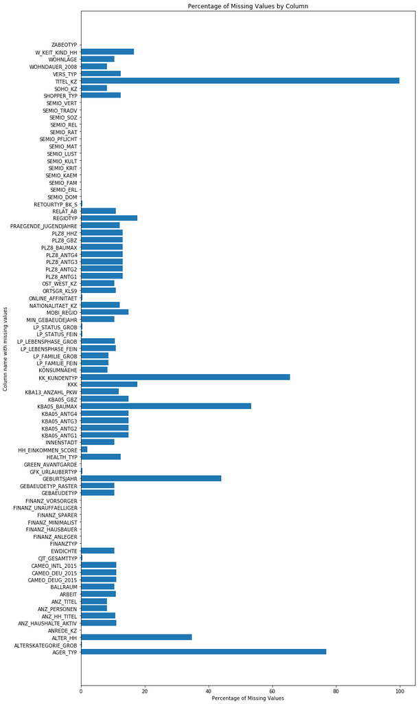

```python
plot_missing_data(missing_data_df)
```

Another way to visualize the data:

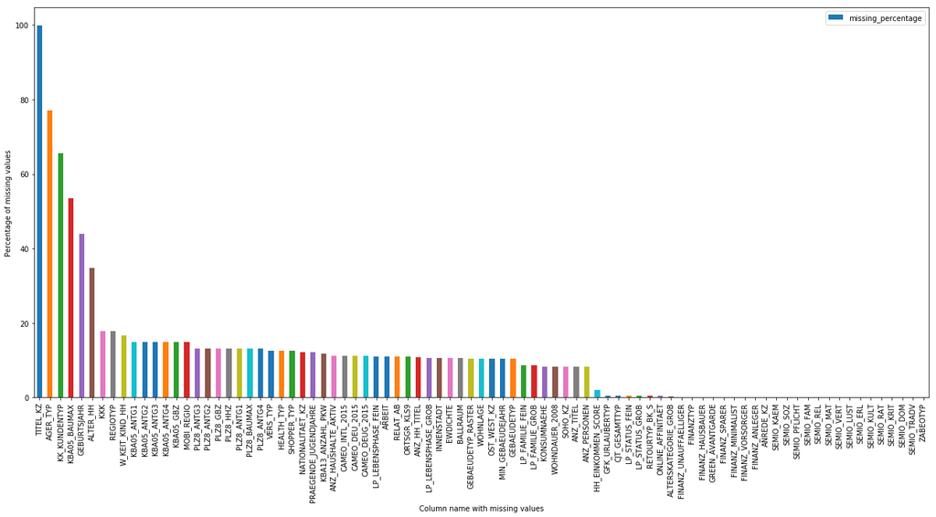

```python
missing_data_df.plot.bar(x='column_name', y='missing_percentage', figsize=(18, 10))
plt.xlabel('Column name with missing values')
plt.ylabel('Percentage of missing values')
plt.xticks(rotation=90)
plt.tight_layout()
plt.show()
```

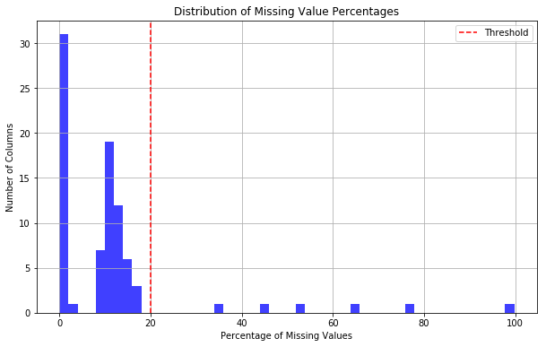

```python
# Investigate patterns in the amount of missing data in each column.

# Plot histogram of missing value counts
plt.figure(figsize=(10, 6))
plt.hist(missing_data_df['missing_percentage'], bins=50, alpha=0.75, color='blue')
plt.title('Distribution of Missing Value Percentages')
plt.xlabel('Percentage of Missing Values')
plt.ylabel('Number of Columns')
plt.grid(True)

# Add a vertical red line
plt.axvline(x=20, color='red', linestyle='--', label='Threshold')
plt.legend()

plt.show()
```

It looks like a threshold can be set at 20% (= red line) because not much information will be lost when the columns with higher values will be dropped.

```python
# Remove the outlier columns from the dataset. (You'll perform other data
# engineering tasks such as re-encoding and imputation later.)

def identify_columns_by_threshold(missing_data_df: pd.DataFrame, threshold: float, mode: str = 'gt') -> list:
    """Identify columns with missing data based on a given threshold and mode."""
    # Mapping of modes to operations
    operations = {
        'gt': lambda x: x > threshold, # greater than
        'lt': lambda x: x < threshold, # less than
    }

    if mode not in operations:
        raise ValueError("Mode should be either 'gt' or 'th'")

    selected_columns = missing_data_df[operations[mode](missing_data_df['missing_percentage'])]['column_name'].tolist()

    return selected_columns

def remove_outlier_columns(df: pd.DataFrame, outlier_columns: list) -> pd.DataFrame:
    """Remove columns with missing data above a given threshold."""
    # Drop the outlier columns from the dataframe
    df_cleaned = df.drop(columns=outlier_columns)

    return df_cleaned

threshold_gt = 20  # columns with more than 20% missing values are considered outliers
outlier_columns = identify_columns_by_threshold(missing_data_df, threshold_gt, mode='gt')

threshold_lt = 1
columns_below_threshold = identify_columns_by_threshold(missing_data_df, threshold_lt, mode='lt')

print(f"These {len(outlier_columns)} columns have more than {threshold_gt}% missing data, and so will be dropped:\n {outlier_columns}\n")
print(f"For comparison:")
print(f"These {len(columns_below_threshold)} columns have less than {threshold_lt}% missing data:\n {columns_below_threshold}")
```

[output not shown]

```python
# get back original dataframe, if something got messed up
#azdias = azdias2
```

```python
azdias = remove_outlier_columns(azdias, outlier_columns)
azdias
```

|  | ALTERSKATEGORIE_GROB | ANREDE_KZ | CJT_GESAMTTYP | FINANZ_MINIMALIST | FINANZ_SPARER | FINANZ_VORSORGER | FINANZ_ANLEGER | FINANZ_UNAUFFAELLIGER | FINANZ_HAUSBAUER | FINANZTYP | ... | PLZ8_ANTG1 | PLZ8_ANTG2 | PLZ8_ANTG3 | PLZ8_ANTG4 | PLZ8_BAUMAX | PLZ8_HHZ | PLZ8_GBZ | ARBEIT | ORTSGR_KLS9 | RELAT_AB |
| --- | --- | --- | --- | --- | --- | --- | --- | --- | --- | --- | --- | --- | --- | --- | --- | --- | --- | --- | --- | --- | --- |
| 0 | 2.0 | 1 | 2.0 | 3 | 4 | 3 | 5 | 5 | 3 | 4 | ... | NaN | NaN | NaN | NaN | NaN | NaN | NaN | NaN | NaN | NaN |
| 1 | 1.0 | 2 | 5.0 | 1 | 5 | 2 | 5 | 4 | 5 | 1 | ... | 2.0 | 3.0 | 2.0 | 1.0 | 1.0 | 5.0 | 4.0 | 3.0 | 5.0 | 4.0 |
| 2 | 3.0 | 2 | 3.0 | 1 | 4 | 1 | 2 | 3 | 5 | 1 | ... | 3.0 | 3.0 | 1.0 | 0.0 | 1.0 | 4.0 | 4.0 | 3.0 | 5.0 | 2.0 |
| 3 | 4.0 | 2 | 2.0 | 4 | 2 | 5 | 2 | 1 | 2 | 6 | ... | 2.0 | 2.0 | 2.0 | 0.0 | 1.0 | 3.0 | 4.0 | 2.0 | 3.0 | 3.0 |
| 4 | 3.0 | 1 | 5.0 | 4 | 3 | 4 | 1 | 3 | 2 | 5 | ... | 2.0 | 4.0 | 2.0 | 1.0 | 2.0 | 3.0 | 3.0 | 4.0 | 6.0 | 5.0 |
| 5 | 1.0 | 2 | 2.0 | 3 | 1 | 5 | 2 | 2 | 5 | 2 | ... | 2.0 | 3.0 | 1.0 | 1.0 | 1.0 | 5.0 | 5.0 | 2.0 | 3.0 | 3.0 |
| 6 | 2.0 | 2 | 5.0 | 1 | 5 | 1 | 5 | 4 | 3 | 4 | ... | 3.0 | 3.0 | 1.0 | 0.0 | 1.0 | 5.0 | 5.0 | 4.0 | 6.0 | 3.0 |
| 7 | 1.0 | 1 | 3.0 | 3 | 3 | 4 | 1 | 3 | 2 | 5 | ... | 3.0 | 3.0 | 1.0 | 0.0 | 1.0 | 4.0 | 4.0 | 2.0 | 5.0 | 2.0 |
| 8 | 3.0 | 1 | 3.0 | 4 | 4 | 2 | 4 | 2 | 2 | 6 | ... | 2.0 | 3.0 | 2.0 | 1.0 | 1.0 | 3.0 | 3.0 | 2.0 | 4.0 | 3.0 |
| 9 | 3.0 | 2 | 4.0 | 2 | 4 | 2 | 3 | 5 | 4 | 1 | ... | 2.0 | 3.0 | 2.0 | 1.0 | 1.0 | 3.0 | 3.0 | 2.0 | 3.0 | 1.0 |
| ... | ... | ... | ... | ... | ... | ... | ... | ... | ... | ... | ... | ... | ... | ... | ... | ... | ... | ... | ... | ... | ... |
| 891211 | 3.0 | 1 | 2.0 | 3 | 2 | 4 | 3 | 3 | 2 | 2 | ... | 1.0 | 4.0 | 2.0 | 0.0 | 2.0 | 3.0 | 2.0 | 3.0 | 5.0 | 5.0 |
| 891212 | 4.0 | 1 | 1.0 | 3 | 1 | 5 | 1 | 1 | 5 | 5 | ... | 1.0 | 3.0 | 3.0 | 2.0 | 5.0 | 4.0 | 1.0 | 3.0 | 9.0 | 5.0 |
| 891213 | 4.0 | 2 | 5.0 | 3 | 3 | 3 | 5 | 3 | 2 | 6 | ... | 2.0 | 4.0 | 2.0 | 1.0 | 2.0 | 5.0 | 5.0 | 3.0 | 4.0 | 4.0 |
| 891214 | 1.0 | 2 | 4.0 | 1 | 5 | 2 | 3 | 3 | 4 | 1 | ... | 1.0 | 4.0 | 3.0 | 2.0 | 5.0 | 5.0 | 2.0 | 3.0 | 7.0 | 3.0 |
| 891215 | 2.0 | 2 | 6.0 | 1 | 5 | 2 | 4 | 5 | 4 | 1 | ... | 2.0 | 4.0 | 2.0 | 1.0 | 2.0 | 4.0 | 4.0 | 2.0 | 5.0 | 2.0 |
| 891216 | 3.0 | 2 | 5.0 | 1 | 4 | 2 | 5 | 4 | 4 | 1 | ... | 3.0 | 2.0 | 0.0 | 0.0 | 1.0 | 2.0 | 3.0 | NaN | NaN | NaN |
| 891217 | 2.0 | 1 | 4.0 | 3 | 3 | 3 | 2 | 2 | 3 | 6 | ... | 1.0 | 3.0 | 3.0 | 2.0 | 4.0 | 5.0 | 3.0 | 4.0 | 6.0 | 5.0 |
| 891218 | 2.0 | 2 | 4.0 | 2 | 4 | 2 | 5 | 4 | 3 | 1 | ... | 4.0 | 2.0 | 0.0 | 0.0 | 1.0 | 3.0 | 4.0 | 2.0 | 2.0 | 3.0 |
| 891219 | 1.0 | 1 | 3.0 | 1 | 5 | 3 | 5 | 5 | 5 | 1 | ... | 1.0 | 4.0 | 3.0 | 1.0 | 5.0 | 1.0 | 1.0 | 4.0 | 7.0 | 5.0 |
| 891220 | 4.0 | 1 | 1.0 | 4 | 2 | 5 | 2 | 1 | 5 | 6 | ... | 3.0 | 3.0 | 1.0 | 0.0 | 1.0 | 4.0 | 4.0 | 3.0 | 4.0 | 5.0 |

891221 rows × 79 columns

```python
missing_data_df_short = calc_missing_data_percentage(azdias)
missing_data_df_short
```

|  | column_name | missing_percentage |
| --- | --- | --- |
| 0 | KKK | 17.74 |
| 1 | REGIOTYP | 17.74 |
| 2 | W_KEIT_KIND_HH | 16.61 |
| 3 | KBA05_ANTG4 | 14.96 |
| 4 | KBA05_ANTG1 | 14.96 |
| 5 | MOBI_REGIO | 14.96 |
| 6 | KBA05_GBZ | 14.96 |
| 7 | KBA05_ANTG2 | 14.96 |
| 8 | KBA05_ANTG3 | 14.96 |
| 9 | PLZ8_GBZ | 13.07 |
| ... | ... | ... |
| 69 | SEMIO_VERT | 0.00 |
| 70 | SEMIO_LUST | 0.00 |
| 71 | SEMIO_ERL | 0.00 |
| 72 | SEMIO_KULT | 0.00 |
| 73 | SEMIO_RAT | 0.00 |
| 74 | SEMIO_KRIT | 0.00 |
| 75 | SEMIO_DOM | 0.00 |
| 76 | SEMIO_KAEM | 0.00 |
| 77 | SEMIO_PFLICHT | 0.00 |
| 78 | ZABEOTYP | 0.00 |

79 rows × 2 columns

For the remaining features let's check if there are any patterns visible:

```python
# Function to calculate the correlation matrix
def calc_correlation(df: pd.DataFrame) -> pd.DataFrame:
    return df.corr()

# Function to visualize the correlation matrix using a heatmap
def plot_correlation_matrix(correlation_matrix: pd.DataFrame) -> None:
    plt.figure(figsize=(15, 15))
    sns.heatmap(correlation_matrix, cmap='coolwarm', annot=False, linewidths=.5)
    plt.title('Correlation Matrix')
    plt.show()

# Function to find the indices of feature columns with correlation value > min_corr_thresh
def high_correlation_features(correlation_matrix: pd.DataFrame, min_corr_thresh: float = 0.8) -> list:
    # Extract upper triangle of the correlation matrix (without diagonal)
    upper_triangle = correlation_matrix.where(np.triu(np.ones(correlation_matrix.shape), k=1).astype(np.bool))

    # Find index of feature columns with correlation greater than min_corr_thresh
    to_drop = [column for column in upper_triangle.columns if any(upper_triangle[column] > min_corr_thresh)]

    return to_drop
```

```python
correlation_matrix = calc_correlation(df=azdias)
```

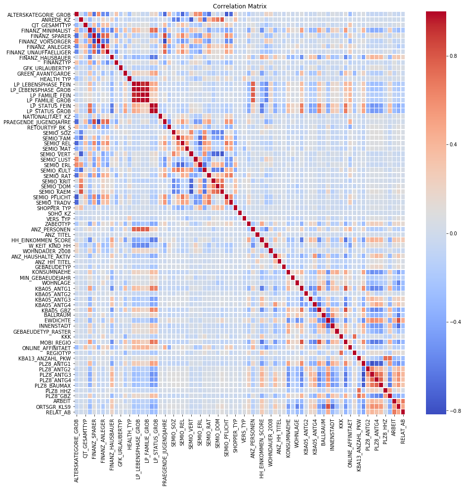

```python
plot_correlation_matrix(correlation_matrix=correlation_matrix)
```

There is a cluster around the main diagonal with several red cells, indicating highly correlated features. Now find those columns:

```python
min_corr_thresh = 0.85
high_corr_columns = high_correlation_features(correlation_matrix=correlation_matrix, min_corr_thresh=min_corr_thresh)
```

```python
print(f"{len(high_corr_columns)} columns with correlation greater than {min_corr_thresh}:\n{high_corr_columns}")
```

```
4 columns with correlation greater than 0.85:
['LP_LEBENSPHASE_GROB', 'LP_FAMILIE_FEIN', 'LP_FAMILIE_GROB', 'LP_STATUS_GROB']
```

#### Discussion 1.1.2: Assess Missing Data in Each Column

**My personal Recap**

At first, it turned out that there were missing or unknown data points that were marked differently and so didn't show up properly when counting them. So I transformed them all to NaN and could identify 3,477,091 more missing data points (8,373,929 in a whole).

By analyzing the amount of missing values in each column it turned out that:

- 6 columns had more than 20% of missing data in them:  
  ['TITEL_KZ', 'AGER_TYP', 'KK_KUNDENTYP', 'KBA05_BAUMAX', 'GEBURTSJAHR', 'ALTER_HH']  
  => as this amount is quite high we decided to drop them from further processing
- 31 columns had less than 1% of missing data in them => so they might be the most helpful columns in the later processing
- the majority of columns (= 48) had missing data between 1% and 20% in them

When I analyzed the remaining columns it turned out that there are 4 columns that are highly correlated:  
['LP_LEBENSPHASE_GROB', 'LP_FAMILIE_FEIN', 'LP_FAMILIE_GROB', 'LP_STATUS_GROB']

#### Step 1.1.3: Assess Missing Data in Each Row

Now, you'll perform a similar assessment for the rows of the dataset. How much data is missing in each row? As with the columns, you should see some groups of points that have a very different numbers of missing values. Divide the data into two subsets: one for data points that are above some threshold for missing values, and a second subset for points below that threshold.

In order to know what to do with the outlier rows, we should see if the distribution of data values on columns that are not missing data (or are missing very little data) are similar or different between the two groups. Select at least five of these columns and compare the distribution of values.

- You can use seaborn's [`countplot()`](https://seaborn.pydata.org/generated/seaborn.countplot.html) function to create a bar chart of code frequencies and matplotlib's [`subplot()`](https://matplotlib.org/api/_as_gen/matplotlib.pyplot.subplot.html) function to put bar charts for the two subplots side by side.
- To reduce repeated code, you might want to write a function that can perform this comparison, taking as one of its arguments a column to be compared.

Depending on what you observe in your comparison, this will have implications on how you approach your conclusions later in the analysis. If the distributions of non-missing features look similar between the data with many missing values and the data with few or no missing values, then we could argue that simply dropping those points from the analysis won't present a major issue. On the other hand, if the data with many missing values looks very different from the data with few or no missing values, then we should make a note on those data as special. We'll revisit these data later on. **Either way, you should continue your analysis for now using just the subset of the data with few or no missing values.**

```python
# How much data is missing in each row of the dataset?
# Calculate the number of missing values in each row
missing_per_row = azdias.isnull().sum(axis=1)
missing_per_row
```

```
0         43
1          0
2          0
3          7
4          0
5          0
6          0
7          0
8          0
9          0
          ..
891211     0
891212     0
891213     0
891214     0
891215     0
891216     3
891217     4
891218     5
891219     0
891220     0
Length: 891221, dtype: int64
```

```python
def analyze_missing_rows(df: pd.DataFrame) -> Dict[str, float]:
    """
    Analyzes the number and percentage of rows with and without missing data in the dataframe.

    Parameters:
    - df (pd.DataFrame): The dataframe to be analyzed.

    Returns:
    - dict: A dictionary containing the counts and percentages of rows with and without missing data.
    """

    total_rows = df.shape[0]
    rows_with_missing = df.isnull().any(axis=1).sum()
    rows_without_missing = total_rows - rows_with_missing

    return {
        'rows_with_missing': rows_with_missing,
        'rows_without_missing': rows_without_missing,
        'percentage_with_missing': (rows_with_missing / total_rows) * 100,
        'percentage_without_missing': (rows_without_missing / total_rows) * 100
    }
```

```python
analysis = analyze_missing_rows(azdias)
print(f"Rows with missing data: {analysis['rows_with_missing']:,} ({analysis['percentage_with_missing']:.2f}%)")
print(f"Rows without missing data: {analysis['rows_without_missing']:,} ({analysis['percentage_without_missing']:.2f}%)")
```

```
Rows with missing data: 268,012 (30.07%)
Rows without missing data: 623,209 (69.93%)
```

=> All in all there are 891,221 rows in `azdias`. At least 623,209 rows will be kept because they don't contain a single missing data point. At most 268,012 rows could be dropped, but this will be analysed in the following cells:

```python
# Calculate the 85th percentile as the threshold
data_split_threshold = missing_per_row.quantile(0.85)
data_split_threshold
```

```
8.0
```

NOTE: I decided to let the threshold be automatically determined, and set it to the 85th percentile. That means that 85% of the data has missing values less than this threshold, and 15% has more. The percentile could be adjusted, but when I look at the histogram it looks feasible to go with 8 as a threshold.

```python
def plot_missing_values_histogram(missing_values: pd.Series, data_split_threshold: int) -> None:
    """
    Plots a histogram of the distribution of missing values per row.

    Parameters:
    - missing_values (pd.Series): A Series containing the number of missing values per row.
    """

    # Plot a histogram of the missing values per row
    plt.figure(figsize=(16, 6))
    plt.hist(missing_values, bins=50, edgecolor='k', alpha=0.7)
    plt.xlabel('Number of Missing Values')
    plt.ylabel('Number of Rows')
    plt.title('Distribution of Missing Values per Row')
    plt.grid(True)

    plt.axvline(x=data_split_threshold, color='red', linestyle='--', label='Data split threshold')
    plt.legend()

    plt.show()
```

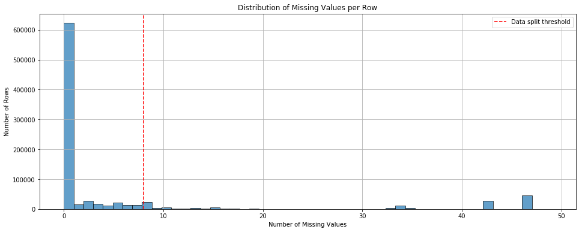

```python
plot_missing_values_histogram(missing_per_row, data_split_threshold)
```

```python
# Divide the data into two subsets
subset1 = azdias[missing_per_row <= data_split_threshold] # the subset with <=8 missing values
subset2 = azdias[missing_per_row > data_split_threshold] # the subset with >8 missing values
```

```python
print(f"Number of rows in subset1: {subset1.shape[0]:,}")
print(f"Number of rows in subset2: {subset2.shape[0]:,}")
print(f"Sum of rows in azdias:     {subset1.shape[0]+subset2.shape[0]:,}")
```

```
Number of rows in subset1: 771,701
Number of rows in subset2: 119,520
Sum of rows in azdias:     891,221
```

```python
# Compare the distribution of values for at least five columns where there are
# no or few missing values, between the two subsets.

def select_random_columns(df: pd.DataFrame, seed: int = 42, count: int = 5) -> List[str]:
    """
    Randomly selects a specified number of columns from a dataframe.

    Parameters:
    - df (pd.DataFrame): The dataframe to select columns from.
    - seed (int): Seed for random selection. Defaults to 42.
    - count (int): Number of columns to select. Defaults to 5.

    Returns:
    - List[str]: List of randomly selected column names.
    """
    random.seed(seed)
    return random.sample(list(df.columns), count)

def plot_column_distributions(subset1: pd.DataFrame, subset2: pd.DataFrame, columns: List[str]) -> None:
    """
    Plots the distribution of values for specified columns in two dataframes using Seaborn's countplot.

    Parameters:
    - subset1 (pd.DataFrame): The first dataframe.
    - subset2 (pd.DataFrame): The second dataframe.
    - columns (List[str]): List of column names to plot.
    """
    for col in columns:
        plt.figure(figsize=(14, 4))

        # Determine the maximum y-axis value between the two subsets for the current column
        max_count = max(subset1[col].value_counts().max(), subset2[col].value_counts().max())
        max_count = max_count * 1.05

        # Plotting for subset1
        plt.subplot(1, 2, 1)
        sns.countplot(x=col, data=subset1, palette="viridis")
        plt.ylim(0, max_count)  # Set y-axis limit
        plt.title(f'Distribution of {col} in Subset1 (= few missing values)')
        plt.xticks(rotation=45)

        # Plotting for subset2
        plt.subplot(1, 2, 2)
        sns.countplot(x=col, data=subset2, palette="viridis")
        plt.ylim(0, max_count)  # Set y-axis limit
        plt.title(f'Distribution of {col} in Subset2 (= more missing values)')
        plt.xticks(rotation=45)

        plt.tight_layout()
        plt.show()
```

```python
selected_cols = select_random_columns(df=azdias, seed=42, count=5)
selected_cols[-1] = 'ANZ_TITEL' # I want this to be evaluated!

print(f"{len(selected_cols)} randomly selected columns for comparison:\n{', '.join(selected_cols)}\n")
```

```
5 randomly selected columns for comparison:
LP_LEBENSPHASE_GROB, FINANZ_MINIMALIST, SEMIO_TRADV, SEMIO_KRIT, ANZ_TITEL
```

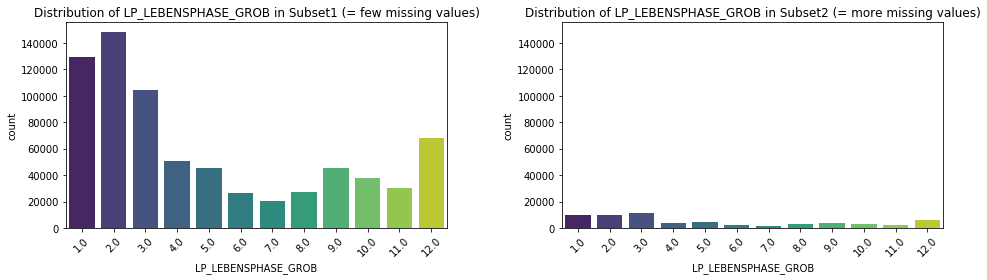

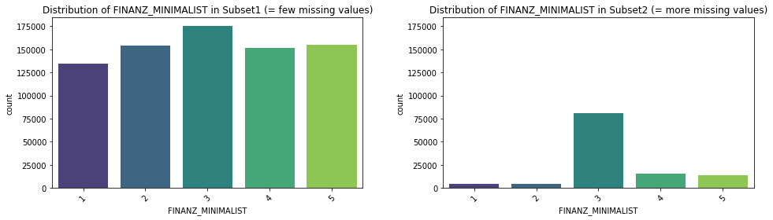

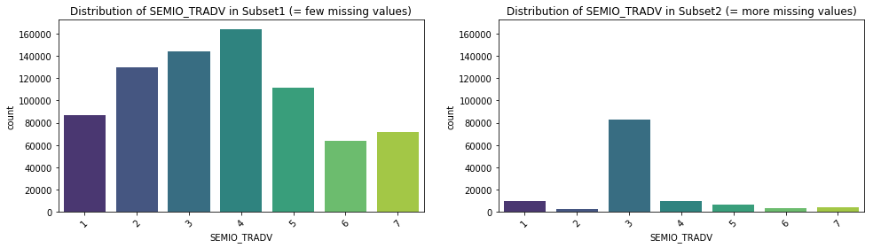

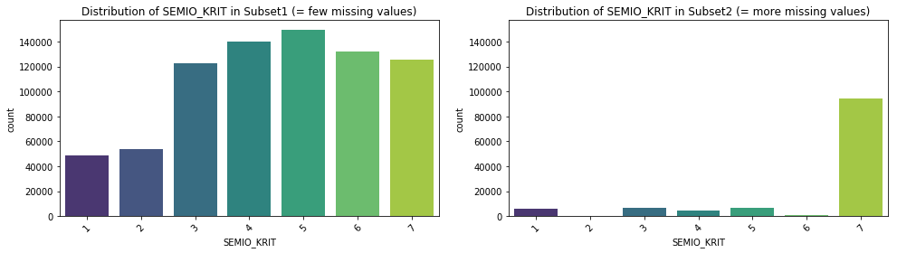

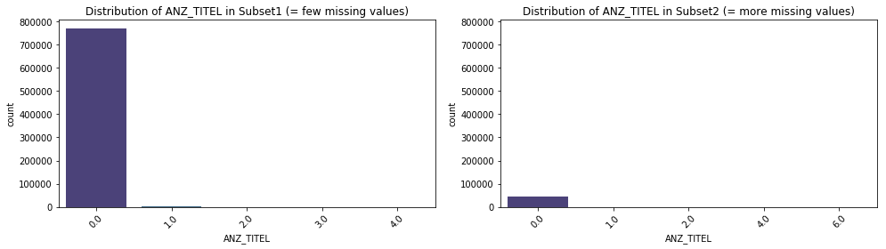

```python
plot_column_distributions(subset1, subset2, selected_cols)
```

```python
def perform_ks_test(column1: pd.Series, column2: pd.Series) -> Tuple[float, float]:
    """
    Performs the Kolmogorov-Smirnov test on two data series.

    Parameters:
    - column1 (pd.Series): The first data series.
    - column2 (pd.Series): The second data series.

    Returns:
    - tuple: The D statistic and the p-value.
    """
    return ks_2samp(column1.dropna(), column2.dropna())

def analyze_distributions(subset1: pd.DataFrame, subset2: pd.DataFrame, columns: List[str]) -> None:
    """
    Analyzes and prints the results of the Kolmogorov-Smirnov test for specified columns in two dataframes.

    Parameters:
    - subset1 (pd.DataFrame): The first dataframe.
    - subset2 (pd.DataFrame): The second dataframe.
    - columns (List[str]): List of column names to analyze.
    """
    for col in columns:
        D, p_value = perform_ks_test(subset1[col], subset2[col])
        print(f"For column '{col}':")
        print(f"  D statistic: {D:.4f}")
        print(f"  p-value: {p_value:.4f}")
        if p_value < 0.05:
            print(f"  Result: The distributions for '{col}' are likely different.\n")
        else:
            print(f"  Result: The distributions for '{col}' are likely the same.\n")
```

```python
analyze_distributions(subset1, subset2, selected_cols)
```

```
For column 'LP_LEBENSPHASE_GROB':
  D statistic: 0.0575
  p-value: 0.0000
  Result: The distributions for 'LP_LEBENSPHASE_GROB' are likely different.

For column 'FINANZ_MINIMALIST':
  D statistic: 0.2936
  p-value: 0.0000
  Result: The distributions for 'FINANZ_MINIMALIST' are likely different.

For column 'SEMIO_TRADV':
  D statistic: 0.3292
  p-value: 0.0000
  Result: The distributions for 'SEMIO_TRADV' are likely different.

For column 'SEMIO_KRIT':
  D statistic: 0.6280
  p-value: 0.0000
  Result: The distributions for 'SEMIO_KRIT' are likely different.

For column 'ANZ_TITEL':
  D statistic: 0.0003
  p-value: 1.0000
  Result: The distributions for 'ANZ_TITEL' are likely the same.
```

=> In deed, the distributions for `ANZ_TITEL` are likely the same while the rest are different. That confirms what I have seen in the histograms.

```python
del subset1, subset2
```

#### Discussion 1.1.3: Assess Missing Data in Each Row

**My personal Recap**

Rows:

- At first I found out that 30% of the rows in `azdias` have missing values: 268,012 rows. They were potential candidates for being removed.
- But to analyse them further I split the data into 2 subsets: the first containing rows with less than 8 missing values, and the second containing rows with more than 8 missing values. The threshold 8 comes from the 85th percentile and is feasible when looking at the histogram.
- This means that from 268,012 potential rows I decided to drop 119,520 rows, meaning that `azdias` now only contains 771,701 rows (with still some missing data).

Columns:

- When looking at the distributions of 5 random columns from each subset it turned out that 4 of them (`LP_LEBENSPHASE_GROB`, `FINANZ_MINIMALIST`, `SEMIO_TRADV`, `SEMIO_KRIT`) were likely differently distributed, while `ANZ_TITEL` was likely distributed the same. From this fact I deduce that it should be OK to drop the column `ANZ_TITEL`. However, the other 4 columns should better be kept, in order to not mess up the data for the upcoming clustering.
- I could have analysed all columns in that way, but for the sake of simplicity I kept all columns (besides `ANZ_TITEL`, as I identified this directly)

```python
azdias.shape
```

```
(891221, 79)
```

```python
# now remove the rows with >8 missing data (= subset1)
azdias = azdias[missing_per_row <= data_split_threshold] # the subset with <=8 missing values

try:
    azdias = azdias.drop('ANZ_TITEL', axis=1)
except KeyError:
    print("Column 'ANZ_TITEL' might have been removed already.")
```

```python
azdias.shape
```

```
(771701, 78)
```

### Step 1.2: Select and Re-Encode Features

Checking for missing data isn't the only way in which you can prepare a dataset for analysis. Since the unsupervised learning techniques to be used will only work on data that is encoded numerically, you need to make a few encoding changes or additional assumptions to be able to make progress. In addition, while almost all of the values in the dataset are encoded using numbers, not all of them represent numeric values. Check the third column of the feature summary (`feat_info`) for a summary of types of measurement.

- For numeric and interval data, these features can be kept without changes.
- Most of the variables in the dataset are ordinal in nature. While ordinal values may technically be non-linear in spacing, make the simplifying assumption that the ordinal variables can be treated as being interval in nature (that is, kept without any changes).
- Special handling may be necessary for the remaining two variable types: categorical, and 'mixed'.

In the first two parts of this sub-step, you will perform an investigation of the categorical and mixed-type features and make a decision on each of them, whether you will keep, drop, or re-encode each. Then, in the last part, you will create a new data frame with only the selected and engineered columns.

Data wrangling is often the trickiest part of the data analysis process, and there's a lot of it to be done here. But stick with it: once you're done with this step, you'll be ready to get to the machine learning parts of the project!

```python
# How many features are there of each data type?
feat_info.type.value_counts()
```

```
ordinal        49
categorical    21
numeric         7
mixed           7
interval        1
Name: type, dtype: int64
```

#### Step 1.2.1: Re-Encode Categorical Features

For categorical data, you would ordinarily need to encode the levels as dummy variables. Depending on the number of categories, perform one of the following:

- For binary (two-level) categoricals that take numeric values, you can keep them without needing to do anything.
- There is one binary variable that takes on non-numeric values. For this one, you need to re-encode the values as numbers or create a dummy variable.
- For multi-level categoricals (three or more values), you can choose to encode the values using multiple dummy variables (e.g. via [OneHotEncoder](http://scikit-learn.org/stable/modules/generated/sklearn.preprocessing.OneHotEncoder.html)), or (to keep things straightforward) just drop them from the analysis. As always, document your choices in the Discussion section.

```python
# Assess categorical variables: which are binary, which are multi-level, and
# which one needs to be re-encoded?

def get_categorical_features(feat_info: pd.DataFrame) -> list:
    """Return a list of categorical features from the feat_info dataframe.

    Args:
        feat_info (pd.DataFrame): Dataframe containing feature information.

    Returns:
        list: List of categorical features present in both feat_info and azdias.
    """
    categorical_features = (
        feat_info[feat_info["type"] == "categorical"]["attribute"].tolist()
    )
    return [feature for feature in categorical_features if feature in azdias.columns]


def classify_categorical_features(
    df: pd.DataFrame, categorical_features: list
) -> tuple:
    """Classify categorical features into binary and multi-level.

    Args:
        df (pd.DataFrame): The dataframe containing the data.
        categorical_features (list): List of categorical features.

    Returns:
        tuple: Tuple containing two dictionaries - binary features and multi-level features.
    """
    binary_features = {}
    multi_level_features = {}

    for feature in categorical_features:
        unique_values = df[feature].dropna().unique()
        if len(unique_values) == 2:
            binary_features[feature] = unique_values
        elif len(unique_values) > 2:
            multi_level_features[feature] = unique_values

    return binary_features, multi_level_features


def get_non_numeric_binary_features(
    df: pd.DataFrame, binary_features: dict
) -> dict:
    """Return binary features that are non-numeric.

    Args:
        df (pd.DataFrame): The dataframe containing the data.
        binary_features (dict): Dictionary of binary features and their unique values.

    Returns:
        dict: Dictionary of non-numeric binary features and their unique values.
    """
    return {
        feature: values
        for feature, values in binary_features.items()
        if df[feature].dtype not in ["int64", "float64"]
    }


def print_features(features: dict, title: str) -> None:
    """Print feature names and their unique values.

    Args:
        features (dict): Dictionary of features and their unique values.
        title (str): Title to be printed before listing the features.

    Returns:
        None
    """
    print(title)
    for feature, values in features.items():
        print(f"{feature}: {values}")
    print("\n")
```

```python
categorical_features = get_categorical_features(feat_info)
binary_features, multi_level_features = classify_categorical_features(azdias, categorical_features)
non_numeric_binary = get_non_numeric_binary_features(azdias, binary_features)
non_numeric_multi = get_non_numeric_binary_features(azdias, multi_level_features)
# merge the two dicts
non_numeric_features = {**non_numeric_binary, **non_numeric_multi}

print_features(binary_features, "Binary features:")
print_features(multi_level_features, "Multi-level features:")
print_features(non_numeric_features, "Non-numeric features that need re-encoding:")
```

```
Binary features:
ANREDE_KZ: [2 1]
GREEN_AVANTGARDE: [0 1]
SOHO_KZ: [ 1.  0.]
VERS_TYP: [ 2.  1.]
OST_WEST_KZ: ['W' 'O']


Multi-level features:
CJT_GESAMTTYP: [ 5.  3.  2.  4.  1.  6.]
FINANZTYP: [1 6 5 2 4 3]
GFK_URLAUBERTYP: [ 10.   1.   5.  12.   9.   3.   8.  11.   4.   7.   2.   6.]
LP_FAMILIE_FEIN: [  5.   1.  10.   2.   7.  11.   8.   4.   6.   9.   3.]
LP_FAMILIE_GROB: [ 3.  1.  5.  2.  4.]
LP_STATUS_FEIN: [  2.   3.   9.   4.   1.  10.   5.   8.   6.   7.]
LP_STATUS_GROB: [ 1.  2.  4.  5.  3.]
NATIONALITAET_KZ: [ 1.  3.  2.]
SHOPPER_TYP: [ 3.  2.  1.  0.]
ZABEOTYP: [5 3 4 1 6 2]
GEBAEUDETYP: [ 8.  1.  3.  2.  6.  4.  5.]
CAMEO_DEUG_2015: ['8' '4' '2' '6' '1' '9' '5' '7' '3']
CAMEO_DEU_2015: ['8A' '4C' '2A' '6B' '8C' '4A' '2D' '1A' '1E' '9D' '5C' '8B' '7A' '5D' '9E'
 '9B' '1B' '3D' '4E' '4B' '3C' '5A' '7B' '9A' '6D' '6E' '2C' '7C' '9C' '7D'
 '5E' '1D' '8D' '6C' '6A' '5B' '4D' '3A' '2B' '7E' '3B' '6F' '5F' '1C']


Non-numeric features that need re-encoding:
OST_WEST_KZ: ['W' 'O']
CAMEO_DEUG_2015: ['8' '4' '2' '6' '1' '9' '5' '7' '3']
CAMEO_DEU_2015: ['8A' '4C' '2A' '6B' '8C' '4A' '2D' '1A' '1E' '9D' '5C' '8B' '7A' '5D' '9E'
 '9B' '1B' '3D' '4E' '4B' '3C' '5A' '7B' '9A' '6D' '6E' '2C' '7C' '9C' '7D'
 '5E' '1D' '8D' '6C' '6A' '5B' '4D' '3A' '2B' '7E' '3B' '6F' '5F' '1C']
```

=> I decide to create dummy variables for all the 3 non-numeric features (and not to just drop them). All the other variables can be left untouched as they are already presented in numeric form (or NaN).

```python
# Re-encode categorical variable(s) to be kept in the analysis.

def one_hot_encode_feature(df: pd.DataFrame, feature: str) -> pd.DataFrame:
    """One-hot encode a single feature in the dataframe based on its data type.

    Args:
        df (pd.DataFrame): The dataframe containing the data.
        feature (str): The feature to be one-hot encoded.

    Returns:
        pd.DataFrame: Dataframe with the one-hot encoded feature.
    """
    # Use pandas get_dummies to one-hot encode the feature
    encoded_df = pd.get_dummies(df[feature], prefix=feature)

    # Drop the original feature from the dataframe
    df = df.drop(columns=[feature])

    # Concatenate the original dataframe with the encoded dataframe
    df_encoded = pd.concat([df, encoded_df], axis=1)

    return df_encoded

def display_encoding_results(original_df: pd.DataFrame, encoded_df: pd.DataFrame) -> None:
    """Display the results of one-hot encoding.

    Args:
        original_df (pd.DataFrame): The original dataframe before encoding.
        encoded_df (pd.DataFrame): The dataframe after one-hot encoding.
    """
    # Display the shape of the original and encoded dataframes
    print(f"Original dataframe shape: {original_df.shape}")
    print(f"Encoded dataframe shape: {encoded_df.shape}")

    # Display the first few rows of the encoded dataframe
    print("\nEncoded dataframe:")
    display(encoded_df.head(100).transpose())

    # Identify new columns added after encoding
    new_columns = set(encoded_df.columns) - set(original_df.columns)
    print(f"\nNumber of new columns added after encoding: {len(new_columns)}")
    print("Some of the new columns:", list(new_columns)[:5])  # Displaying first 5 new columns for brevity
```

```python
non_numeric_features = ['OST_WEST_KZ','CAMEO_DEUG_2015','CAMEO_DEU_2015']

azdias_encoded = azdias
for feature in non_numeric_features:
    azdias_encoded = one_hot_encode_feature(azdias_encoded, feature)
```

```python
pd.options.display.max_columns=20 # default: 20
pd.options.display.max_rows=300 # default: 60

display_encoding_results(azdias, azdias_encoded)
```

```
Original dataframe shape: (771701, 78)
Encoded dataframe shape: (771701, 130)

Encoded dataframe:
```

|  | 1 | 2 | 3 | 4 | 5 | 6 | 7 | 8 | 9 | 10 | ... | 118 | 119 | 120 | 121 | 122 | 123 | 124 | 125 | 126 | 127 |
| --- | --- | --- | --- | --- | --- | --- | --- | --- | --- | --- | --- | --- | --- | --- | --- | --- | --- | --- | --- | --- | --- |
| ALTERSKATEGORIE_GROB | 1 | 3 | 4 | 3 | 1 | 2 | 1 | 3 | 3 | 3 | ... | 3 | 4 | 4 | 4 | 2 | 2 | 3 | 3 | 3 | 4 |
| ANREDE_KZ | 2 | 2 | 2 | 1 | 2 | 2 | 1 | 1 | 2 | 2 | ... | 1 | 2 | 2 | 2 | 2 | 1 | 1 | 2 | 1 | 1 |
| CJT_GESAMTTYP | 5 | 3 | 2 | 5 | 2 | 5 | 3 | 3 | 4 | 1 | ... | 2 | 1 | 3 | 2 | 6 | 4 | 5 | 3 | 6 | 6 |
| FINANZ_MINIMALIST | 1 | 1 | 4 | 4 | 3 | 1 | 3 | 4 | 2 | 2 | ... | 4 | 3 | 5 | 4 | 1 | 4 | 5 | 2 | 3 | 4 |
| FINANZ_SPARER | 5 | 4 | 2 | 3 | 1 | 5 | 3 | 4 | 4 | 2 | ... | 2 | 1 | 1 | 1 | 5 | 3 | 2 | 1 | 3 | 1 |
| FINANZ_VORSORGER | 2 | 1 | 5 | 4 | 5 | 1 | 4 | 2 | 2 | 5 | ... | 3 | 5 | 5 | 5 | 1 | 2 | 4 | 5 | 4 | 5 |
| FINANZ_ANLEGER | 5 | 2 | 2 | 1 | 2 | 5 | 1 | 4 | 3 | 3 | ... | 1 | 1 | 3 | 1 | 4 | 3 | 1 | 1 | 2 | 1 |
| FINANZ_UNAUFFAELLIGER | 4 | 3 | 1 | 3 | 2 | 4 | 3 | 2 | 5 | 1 | ... | 3 | 1 | 1 | 2 | 5 | 5 | 3 | 1 | 1 | 2 |
| FINANZ_HAUSBAUER | 5 | 5 | 2 | 2 | 5 | 3 | 2 | 2 | 4 | 5 | ... | 2 | 5 | 2 | 3 | 4 | 1 | 1 | 5 | 3 | 4 |
| FINANZTYP | 1 | 1 | 6 | 5 | 2 | 4 | 5 | 6 | 1 | 6 | ... | 5 | 2 | 2 | 2 | 4 | 3 | 6 | 5 | 6 | 5 |
| GFK_URLAUBERTYP | 10 | 10 | 1 | 5 | 1 | 12 | 9 | 3 | 12 | 8 | ... | 12 | 3 | 10 | 7 | 1 | 8 | 7 | 7 | 8 | 3 |
| GREEN_AVANTGARDE | 0 | 1 | 0 | 0 | 0 | 0 | 0 | 1 | 1 | 0 | ... | 0 | 0 | 0 | 1 | 0 | 1 | 1 | 0 | 0 | 0 |
| HEALTH_TYP | 3 | 3 | 2 | 3 | 3 | 2 | 1 | 3 | 2 | 2 | ... | 1 | 2 | 1 | 2 | 1 | 3 | 3 | 3 | 3 | 2 |
| LP_LEBENSPHASE_FEIN | 21 | 3 | NaN | 32 | 8 | 2 | 5 | 10 | 4 | 6 | ... | NaN | 8 | 38 | 13 | 10 | 35 | 39 | 31 | 2 | 6 |
| LP_LEBENSPHASE_GROB | 6 | 1 | NaN | 10 | 2 | 1 | 2 | 3 | 1 | 2 | ... | NaN | 2 | 12 | 3 | 3 | 11 | 12 | 10 | 1 | 2 |
| LP_FAMILIE_FEIN | 5 | 1 | NaN | 10 | 1 | 1 | 1 | 1 | 1 | 1 | ... | NaN | 1 | 10 | 1 | 1 | 11 | 10 | 10 | 1 | 1 |
| LP_FAMILIE_GROB | 3 | 1 | NaN | 5 | 1 | 1 | 1 | 1 | 1 | 1 | ... | NaN | 1 | 5 | 1 | 1 | 5 | 5 | 5 | 1 | 1 |
| LP_STATUS_FEIN | 2 | 3 | 9 | 3 | 4 | 2 | 1 | 10 | 3 | 1 | ... | 9 | 3 | 9 | 10 | 8 | 10 | 10 | 1 | 1 | 1 |
| LP_STATUS_GROB | 1 | 2 | 4 | 2 | 2 | 1 | 1 | 5 | 2 | 1 | ... | 4 | 2 | 4 | 5 | 4 | 5 | 5 | 1 | 1 | 1 |
| NATIONALITAET_KZ | 1 | 1 | 1 | 1 | 1 | 1 | 1 | 1 | 1 | 1 | ... | 1 | 1 | 1 | 1 | 1 | 1 | 1 | 1 | 1 | 1 |
| PRAEGENDE_JUGENDJAHRE | 14 | 15 | 8 | 8 | 3 | 10 | 8 | 11 | 15 | 3 | ... | 8 | 1 | 5 | 6 | 14 | 11 | 9 | 5 | 10 | 3 |
| RETOURTYP_BK_S | 1 | 3 | 2 | 5 | 3 | 4 | 5 | 4 | 4 | 5 | ... | 5 | 5 | 2 | 5 | 4 | 3 | 5 | 5 | 5 | 4 |
| SEMIO_SOZ | 5 | 4 | 5 | 6 | 2 | 2 | 7 | 4 | 2 | 5 | ... | 3 | 3 | 5 | 5 | 2 | 7 | 6 | 2 | 6 | 3 |
| SEMIO_FAM | 4 | 1 | 1 | 4 | 4 | 5 | 7 | 5 | 1 | 2 | ... | 2 | 1 | 3 | 3 | 5 | 7 | 2 | 3 | 5 | 6 |
| SEMIO_REL | 4 | 3 | 2 | 4 | 7 | 5 | 7 | 4 | 1 | 3 | ... | 4 | 2 | 1 | 1 | 5 | 6 | 4 | 1 | 4 | 3 |
| SEMIO_MAT | 3 | 3 | 1 | 2 | 4 | 7 | 5 | 1 | 3 | 5 | ... | 6 | 5 | 2 | 1 | 7 | 7 | 1 | 3 | 4 | 6 |
| SEMIO_VERT | 1 | 4 | 4 | 7 | 2 | 2 | 6 | 5 | 2 | 5 | ... | 7 | 2 | 4 | 4 | 2 | 7 | 7 | 2 | 5 | 6 |
| SEMIO_LUST | 2 | 4 | 4 | 4 | 2 | 6 | 2 | 6 | 6 | 6 | ... | 6 | 7 | 4 | 7 | 3 | 2 | 4 | 1 | 6 | 7 |
| SEMIO_ERL | 2 | 6 | 7 | 4 | 2 | 5 | 2 | 4 | 6 | 6 | ... | 4 | 7 | 7 | 7 | 5 | 2 | 4 | 6 | 4 | 7 |
| SEMIO_KULT | 3 | 3 | 4 | 6 | 5 | 5 | 7 | 5 | 3 | 1 | ... | 5 | 1 | 4 | 1 | 5 | 7 | 5 | 3 | 6 | 6 |

[output cut: 100 more lines]

130 rows × 100 columns

```
Number of new columns added after encoding: 55
Some of the new columns: ['CAMEO_DEUG_2015_5', 'CAMEO_DEU_2015_4C', 'CAMEO_DEUG_2015_9', 'CAMEO_DEU_2015_6A', 'CAMEO_DEU_2015_7C']
```

```python
azdias = azdias_encoded
azdias.shape
```

```
(771701, 130)
```

```python
del azdias_encoded
```

#### Discussion 1.2.1: Re-Encode Categorical Features

**My personal Recap**

At first I picked out the categorical features, and split them into binary and multi-level features. Among them were 3 features that were represented as strings instead of numbers: `OST_WEST_KZ`, `CAMEO_DEUG_2015`, `CAMEO_DEU_2015`

While others decided to delete them for ease of simplicity (e.g. [katba-caroline.com](https://katba-caroline.com/wp-content/uploads/2018/12/Identify_Customer_Segments-1.html#Discussion-1.2.1:-Re-Encode-Categorical-Features)) I don't want to do this at this point. Using `pd.get_dummies()` makes it possible to one-hot-encode the features, so why not use it. Ok, the final dataframe increased (by 55 columns), resulting in a shape of 771,701 rows x 130 columns. But still my computational power suffices so I'd prefer to keep them all and not drop any feature here.

Actually, I'd also do a mapping of the numeric labels to values beginning at 0, in order to have them all standardized to roughly the same range, like this:

ANREDE_KZ: 1 -> 0, 2 -> 1  
SOHO_KZ: 0.0 -> 0, 1.0 -> 1  
...

I'd use sklearn's LabelEncoder. But I spare myself this here.

#### Step 1.2.2: Engineer Mixed-Type Features

There are a handful of features that are marked as "mixed" in the feature summary that require special treatment in order to be included in the analysis. There are two in particular that deserve attention; the handling of the rest are up to your own choices:

- "PRAEGENDE_JUGENDJAHRE" combines information on three dimensions: generation by decade, movement (mainstream vs. avantgarde), and nation (east vs. west). While there aren't enough levels to disentangle east from west, you should create two new variables to capture the other two dimensions: an interval-type variable for decade, and a binary variable for movement.
- "CAMEO_INTL_2015" combines information on two axes: wealth and life stage. Break up the two-digit codes by their 'tens'-place and 'ones'-place digits into two new ordinal variables (which, for the purposes of this project, is equivalent to just treating them as their raw numeric values).
- If you decide to keep or engineer new features around the other mixed-type features, make sure you note your steps in the Discussion section.

Be sure to check `Data_Dictionary.md` for the details needed to finish these tasks.

```python
mixed_features = feat_info[feat_info.type == 'mixed'].attribute
print(mixed_features)
```

```
15      LP_LEBENSPHASE_FEIN
16      LP_LEBENSPHASE_GROB
22    PRAEGENDE_JUGENDJAHRE
56                 WOHNLAGE
59          CAMEO_INTL_2015
64             KBA05_BAUMAX
79              PLZ8_BAUMAX
Name: attribute, dtype: object
```

```python
# Filter out any features from mixed_features that have already been dropped from azdias
valid_mixed_features = [feature for feature in mixed_features if feature in azdias.columns]

# Now display the samples
print(azdias[valid_mixed_features].sample(5).transpose())
```

```
                      690443 225419 715996 718290 19708
LP_LEBENSPHASE_FEIN        1     13     19      3      7
LP_LEBENSPHASE_GROB        1      3      5      1      2
PRAEGENDE_JUGENDJAHRE     14      9      8     14      8
WOHNLAGE                   2      5      7      3      7
CAMEO_INTL_2015           51     32     22     51     25
PLZ8_BAUMAX                5      1      1      1      1
```

=> 'PRAEGENDE_JUGENDJAHRE' and 'CAMEO_INTL_2015' will be investigated below, 'KBA05_BAUMAX' has already been dropped above, and I will drop the other 4 columns later.

Taken from `Data_dictionary.md`:

**PRAEGENDE_JUGENDJAHRE**  
Dominating movement of person's youth (avantgarde vs. mainstream; east vs. west)

- 1: 40s - war years (Mainstream, E+W)
- 2: 40s - reconstruction years (Avantgarde, E+W)
- 3: 50s - economic miracle (Mainstream, E+W)
- 4: 50s - milk bar / Individualisation (Avantgarde, E+W)
- 5: 60s - economic miracle (Mainstream, E+W)
- 6: 60s - generation 68 / student protestors (Avantgarde, W)
- 7: 60s - opponents to the building of the Wall (Avantgarde, E)
- 8: 70s - family orientation (Mainstream, E+W)
- 9: 70s - peace movement (Avantgarde, E+W)
- 10: 80s - Generation Golf (Mainstream, W)
- 11: 80s - ecological awareness (Avantgarde, W)
- 12: 80s - FDJ / communist party youth organisation (Mainstream, E)
- 13: 80s - Swords into ploughshares (Avantgarde, E)
- 14: 90s - digital media kids (Mainstream, E+W)
- 15: 90s - ecological awareness (Avantgarde, E+W)

```python
# Investigate "PRAEGENDE_JUGENDJAHRE" and engineer two new variables.
azdias[['PRAEGENDE_JUGENDJAHRE']].head()
```

|  | PRAEGENDE_JUGENDJAHRE |
| --- | --- |
| 1 | 14.0 |
| 2 | 15.0 |
| 3 | 8.0 |
| 4 | 8.0 |
| 5 | 3.0 |

```python
azdias[['PRAEGENDE_JUGENDJAHRE']].describe()
```

|  | PRAEGENDE_JUGENDJAHRE |
| --- | --- |
| count | 747372.000000 |
| mean | 9.258759 |
| std | 4.025657 |
| min | 1.000000 |
| 25% | 6.000000 |
| 50% | 9.000000 |
| 75% | 14.000000 |
| max | 15.000000 |

```python
azdias[['PRAEGENDE_JUGENDJAHRE']].info()
```

```
<class 'pandas.core.frame.DataFrame'>
Int64Index: 771701 entries, 1 to 891220
Data columns (total 1 columns):
PRAEGENDE_JUGENDJAHRE    747372 non-null float64
dtypes: float64(1)
memory usage: 11.8 MB
```

```python
# Extract the decade intervals and map them to interval indices
def map_decade(value: int) -> int:
    """
    Maps the PRAEGENDE_JUGENDJAHRE value to its corresponding decade interval index.
    """
    decade_mapping = {
        1: 0, 2: 0,  # 40s
        3: 1, 4: 1,  # 50s
        5: 2, 6: 2, 7: 2,  # 60s
        8: 3, 9: 3,  # 70s
        10: 4, 11: 4, 12: 4, 13: 4,  # 80s
        14: 5, 15: 5  # 90s
    }
    return decade_mapping.get(value, None)

def map_movement(value: int) -> int:
    """
    Maps the PRAEGENDE_JUGENDJAHRE value to its corresponding movement (0 for Mainstream, 1 for Avantgarde).
    """
    movement_mapping = {
        1: 0, 2: 1, 3: 0, 4: 1, 5: 0, 6: 1, 7: 1, 8: 0, 9: 1,
        10: 0, 11: 1, 12: 0, 13: 1, 14: 0, 15: 1
    }
    return movement_mapping.get(value, None)
```

```python
# Apply the mapping functions to the dataframe
azdias['DECADE'] = azdias['PRAEGENDE_JUGENDJAHRE'].apply(map_decade)
azdias['MOVEMENT'] = azdias['PRAEGENDE_JUGENDJAHRE'].apply(map_movement)
```

```python
# Print basic statistics for the new variables
print("Descriptive Statistics for DECADE:")
print(azdias['DECADE'].describe())
print("\nValue Counts for DECADE:")
print(azdias['DECADE'].value_counts(normalize=True) * 100)  # Displaying as percentages

print("\nDescriptive Statistics for MOVEMENT:")
print(azdias['MOVEMENT'].describe())
print("\nValue Counts for MOVEMENT:")
print(azdias['MOVEMENT'].value_counts(normalize=True) * 100)  # Displaying as percentages

# Check for missing values in the new columns
missing_decade = azdias['DECADE'].isnull().sum()
missing_movement = azdias['MOVEMENT'].isnull().sum()
print(f"\nMissing values in DECADE: {missing_decade:,}")
print(f"Missing values in MOVEMENT: {missing_movement:,}")
```

```
Descriptive Statistics for DECADE:
count    747372.000000
mean          3.324373
std           1.458013
min           0.000000
25%           2.000000
50%           3.000000
75%           5.000000
max           5.000000
Name: DECADE, dtype: float64

Value Counts for DECADE:
5.0    29.133952
3.0    22.802299
4.0    19.647244
2.0    15.014076
1.0     9.743474
0.0     3.658954
Name: DECADE, dtype: float64

Descriptive Statistics for MOVEMENT:
count    747372.000000
mean          0.227672
std           0.419330
min           0.000000
25%           0.000000
50%           0.000000
75%           0.000000
max           1.000000
Name: MOVEMENT, dtype: float64

Value Counts for MOVEMENT:
0.0    77.232757
1.0    22.767243
Name: MOVEMENT, dtype: float64

Missing values in DECADE: 24,329
Missing values in MOVEMENT: 24,329
```

(I will drop the original column down below)

```python
# Investigate "CAMEO_INTL_2015" and engineer two new variables.
```

From `Data_Dictionary.md`:

**CAMEO_INTL_2015**:

- 11: Wealthy Households - Pre-Family Couples & Singles
- 12: Wealthy Households - Young Couples With Children
- 13: Wealthy Households - Families With School Age Children
- 14: Wealthy Households - Older Families & Mature Couples
- 15: Wealthy Households - Elders In Retirement
- 21: Prosperous Households - Pre-Family Couples & Singles
- 22: Prosperous Households - Young Couples With Children
- 23: Prosperous Households - Families With School Age Children
- 24: Prosperous Households - Older Families & Mature Couples
- 25: Prosperous Households - Elders In Retirement
- 31: Comfortable Households - Pre-Family Couples & Singles
- 32: Comfortable Households - Young Couples With Children
- 33: Comfortable Households - Families With School Age Children
- 34: Comfortable Households - Older Families & Mature Couples
- 35: Comfortable Households - Elders In Retirement
- 41: Less Affluent Households - Pre-Family Couples & Singles
- 42: Less Affluent Households - Young Couples With Children
- 43: Less Affluent Households - Families With School Age Children
- 44: Less Affluent Households - Older Families & Mature Couples
- 45: Less Affluent Households - Elders In Retirement
- 51: Poorer Households - Pre-Family Couples & Singles
- 52: Poorer Households - Young Couples With Children
- 53: Poorer Households - Families With School Age Children
- 54: Poorer Households - Older Families & Mature Couples
- 55: Poorer Households - Elders In Retirement

```python
type(azdias[['CAMEO_INTL_2015']].iloc[0,0])
```

```
str
```

=> So the entries in `CAMEO_INTL_2015` are given as strings!

```python
azdias[['CAMEO_INTL_2015']].head()
```

|  | CAMEO_INTL_2015 |
| --- | --- |
| 1 | 51 |
| 2 | 24 |
| 3 | 12 |
| 4 | 43 |
| 5 | 54 |

=> I can split the 2-digit number into two single digits: the first representing the wealth level, the second representing the life stage.

```python
def map_wealth_level(value: str) -> int:
    """
    Extracts the wealth level from the value.
    """
    if pd.isna(value) or not value.isdigit():
        return value
    return int(value[0])  # Extract the first character and convert to integer

def map_life_stage(value: str) -> int:
    """
    Extracts the life stage from the value.
    """
    if pd.isna(value) or not value.isdigit():
        return value
    return int(value[1])  # Extract the second character and convert to integer
```

```python
azdias['WEALTH_LEVEL'] = azdias['CAMEO_INTL_2015'].apply(map_wealth_level)
azdias['LIFE_STAGE'] = azdias['CAMEO_INTL_2015'].apply(map_life_stage)
```

```python
azdias[['WEALTH_LEVEL', 'LIFE_STAGE']].head()
```

|  | WEALTH_LEVEL | LIFE_STAGE |
| --- | --- | --- |
| 1 | 5.0 | 1.0 |
| 2 | 2.0 | 4.0 |
| 3 | 1.0 | 2.0 |
| 4 | 4.0 | 3.0 |
| 5 | 5.0 | 4.0 |

```python
type(azdias[['WEALTH_LEVEL']].iloc[0,0])
```

```
numpy.float64
```

=> Even though I made the functions return integers the values are given as float. This seems to be reasoned by the fact that older pandas versions handle NaNs as a special floating-point value.

```python
print("Descriptive Statistics for WEALTH_LEVEL:")
print(azdias['WEALTH_LEVEL'].describe())
print("\nValue Counts for WEALTH_LEVEL:")
print(azdias['WEALTH_LEVEL'].value_counts(normalize=True) * 100)  # Displaying as percentages

print("Descriptive Statistics for LIFE_STAGE:")
print(azdias['LIFE_STAGE'].describe())
print("\nValue Counts for LIFE_STAGE:")
print(azdias['LIFE_STAGE'].value_counts(normalize=True) * 100)  # Displaying as percentages

# Check for missing values in the new columns
missing_decade = azdias['DECADE'].isnull().sum()
missing_movement = azdias['MOVEMENT'].isnull().sum()
print(f"\nMissing values in DECADE: {missing_decade:,}")
print(f"Missing values in MOVEMENT: {missing_movement:,}")
```

```
Descriptive Statistics for WEALTH_LEVEL:
count    768362.000000
mean          3.276115
std           1.465362
min           1.000000
25%           2.000000
50%           4.000000
75%           5.000000
max           5.000000
Name: WEALTH_LEVEL, dtype: float64

Value Counts for WEALTH_LEVEL:
5.0    28.613076
4.0    24.137451
2.0    23.741804
1.0    15.005167
3.0     8.502503
Name: WEALTH_LEVEL, dtype: float64
Descriptive Statistics for LIFE_STAGE:
count    768362.000000
mean          2.869839
std           1.488175
min           1.000000
25%           1.000000
50%           3.000000
75%           4.000000
max           5.000000
Name: LIFE_STAGE, dtype: float64

Value Counts for LIFE_STAGE:
1.0    31.182568
4.0    29.435474
3.0    14.841442
5.0    14.818015
2.0     9.722501
Name: LIFE_STAGE, dtype: float64

Missing values in DECADE: 24,329
Missing values in MOVEMENT: 24,329
```

```python
print("\nEncoded dataframe:")
display(azdias.head(100).transpose())
```

```
Encoded dataframe:
```

|  | 1 | 2 | 3 | 4 | 5 | 6 | 7 | 8 | 9 | 10 | ... | 118 | 119 | 120 | 121 | 122 | 123 | 124 | 125 | 126 | 127 |
| --- | --- | --- | --- | --- | --- | --- | --- | --- | --- | --- | --- | --- | --- | --- | --- | --- | --- | --- | --- | --- | --- |
| ALTERSKATEGORIE_GROB | 1 | 3 | 4 | 3 | 1 | 2 | 1 | 3 | 3 | 3 | ... | 3 | 4 | 4 | 4 | 2 | 2 | 3 | 3 | 3 | 4 |
| ANREDE_KZ | 2 | 2 | 2 | 1 | 2 | 2 | 1 | 1 | 2 | 2 | ... | 1 | 2 | 2 | 2 | 2 | 1 | 1 | 2 | 1 | 1 |
| CJT_GESAMTTYP | 5 | 3 | 2 | 5 | 2 | 5 | 3 | 3 | 4 | 1 | ... | 2 | 1 | 3 | 2 | 6 | 4 | 5 | 3 | 6 | 6 |
| FINANZ_MINIMALIST | 1 | 1 | 4 | 4 | 3 | 1 | 3 | 4 | 2 | 2 | ... | 4 | 3 | 5 | 4 | 1 | 4 | 5 | 2 | 3 | 4 |
| FINANZ_SPARER | 5 | 4 | 2 | 3 | 1 | 5 | 3 | 4 | 4 | 2 | ... | 2 | 1 | 1 | 1 | 5 | 3 | 2 | 1 | 3 | 1 |
| FINANZ_VORSORGER | 2 | 1 | 5 | 4 | 5 | 1 | 4 | 2 | 2 | 5 | ... | 3 | 5 | 5 | 5 | 1 | 2 | 4 | 5 | 4 | 5 |
| FINANZ_ANLEGER | 5 | 2 | 2 | 1 | 2 | 5 | 1 | 4 | 3 | 3 | ... | 1 | 1 | 3 | 1 | 4 | 3 | 1 | 1 | 2 | 1 |
| FINANZ_UNAUFFAELLIGER | 4 | 3 | 1 | 3 | 2 | 4 | 3 | 2 | 5 | 1 | ... | 3 | 1 | 1 | 2 | 5 | 5 | 3 | 1 | 1 | 2 |
| FINANZ_HAUSBAUER | 5 | 5 | 2 | 2 | 5 | 3 | 2 | 2 | 4 | 5 | ... | 2 | 5 | 2 | 3 | 4 | 1 | 1 | 5 | 3 | 4 |
| FINANZTYP | 1 | 1 | 6 | 5 | 2 | 4 | 5 | 6 | 1 | 6 | ... | 5 | 2 | 2 | 2 | 4 | 3 | 6 | 5 | 6 | 5 |
| GFK_URLAUBERTYP | 10 | 10 | 1 | 5 | 1 | 12 | 9 | 3 | 12 | 8 | ... | 12 | 3 | 10 | 7 | 1 | 8 | 7 | 7 | 8 | 3 |
| GREEN_AVANTGARDE | 0 | 1 | 0 | 0 | 0 | 0 | 0 | 1 | 1 | 0 | ... | 0 | 0 | 0 | 1 | 0 | 1 | 1 | 0 | 0 | 0 |
| HEALTH_TYP | 3 | 3 | 2 | 3 | 3 | 2 | 1 | 3 | 2 | 2 | ... | 1 | 2 | 1 | 2 | 1 | 3 | 3 | 3 | 3 | 2 |
| LP_LEBENSPHASE_FEIN | 21 | 3 | NaN | 32 | 8 | 2 | 5 | 10 | 4 | 6 | ... | NaN | 8 | 38 | 13 | 10 | 35 | 39 | 31 | 2 | 6 |
| LP_LEBENSPHASE_GROB | 6 | 1 | NaN | 10 | 2 | 1 | 2 | 3 | 1 | 2 | ... | NaN | 2 | 12 | 3 | 3 | 11 | 12 | 10 | 1 | 2 |
| LP_FAMILIE_FEIN | 5 | 1 | NaN | 10 | 1 | 1 | 1 | 1 | 1 | 1 | ... | NaN | 1 | 10 | 1 | 1 | 11 | 10 | 10 | 1 | 1 |
| LP_FAMILIE_GROB | 3 | 1 | NaN | 5 | 1 | 1 | 1 | 1 | 1 | 1 | ... | NaN | 1 | 5 | 1 | 1 | 5 | 5 | 5 | 1 | 1 |
| LP_STATUS_FEIN | 2 | 3 | 9 | 3 | 4 | 2 | 1 | 10 | 3 | 1 | ... | 9 | 3 | 9 | 10 | 8 | 10 | 10 | 1 | 1 | 1 |
| LP_STATUS_GROB | 1 | 2 | 4 | 2 | 2 | 1 | 1 | 5 | 2 | 1 | ... | 4 | 2 | 4 | 5 | 4 | 5 | 5 | 1 | 1 | 1 |
| NATIONALITAET_KZ | 1 | 1 | 1 | 1 | 1 | 1 | 1 | 1 | 1 | 1 | ... | 1 | 1 | 1 | 1 | 1 | 1 | 1 | 1 | 1 | 1 |
| PRAEGENDE_JUGENDJAHRE | 14 | 15 | 8 | 8 | 3 | 10 | 8 | 11 | 15 | 3 | ... | 8 | 1 | 5 | 6 | 14 | 11 | 9 | 5 | 10 | 3 |
| RETOURTYP_BK_S | 1 | 3 | 2 | 5 | 3 | 4 | 5 | 4 | 4 | 5 | ... | 5 | 5 | 2 | 5 | 4 | 3 | 5 | 5 | 5 | 4 |
| SEMIO_SOZ | 5 | 4 | 5 | 6 | 2 | 2 | 7 | 4 | 2 | 5 | ... | 3 | 3 | 5 | 5 | 2 | 7 | 6 | 2 | 6 | 3 |
| SEMIO_FAM | 4 | 1 | 1 | 4 | 4 | 5 | 7 | 5 | 1 | 2 | ... | 2 | 1 | 3 | 3 | 5 | 7 | 2 | 3 | 5 | 6 |
| SEMIO_REL | 4 | 3 | 2 | 4 | 7 | 5 | 7 | 4 | 1 | 3 | ... | 4 | 2 | 1 | 1 | 5 | 6 | 4 | 1 | 4 | 3 |
| SEMIO_MAT | 3 | 3 | 1 | 2 | 4 | 7 | 5 | 1 | 3 | 5 | ... | 6 | 5 | 2 | 1 | 7 | 7 | 1 | 3 | 4 | 6 |
| SEMIO_VERT | 1 | 4 | 4 | 7 | 2 | 2 | 6 | 5 | 2 | 5 | ... | 7 | 2 | 4 | 4 | 2 | 7 | 7 | 2 | 5 | 6 |
| SEMIO_LUST | 2 | 4 | 4 | 4 | 2 | 6 | 2 | 6 | 6 | 6 | ... | 6 | 7 | 4 | 7 | 3 | 2 | 4 | 1 | 6 | 7 |
| SEMIO_ERL | 2 | 6 | 7 | 4 | 2 | 5 | 2 | 4 | 6 | 6 | ... | 4 | 7 | 7 | 7 | 5 | 2 | 4 | 6 | 4 | 7 |
| SEMIO_KULT | 3 | 3 | 4 | 6 | 5 | 5 | 7 | 5 | 3 | 1 | ... | 5 | 1 | 4 | 1 | 5 | 7 | 5 | 3 | 6 | 6 |

[output cut: 104 more lines]

134 rows × 100 columns

```python
valid_mixed_features
```

```
['LP_LEBENSPHASE_FEIN',
 'LP_LEBENSPHASE_GROB',
 'PRAEGENDE_JUGENDJAHRE',
 'WOHNLAGE',
 'CAMEO_INTL_2015',
 'PLZ8_BAUMAX']
```

```python
for feature in valid_mixed_features:
    try:
        azdias.drop(feature, inplace=True, axis=1)
    except KeyError:
        print(f"Column {feature} might have been removed already.")
```

```python
azdias.shape
```

```
(771701, 128)
```

#### Discussion 1.2.2: Engineer Mixed-Type Features

**My personal Recap**

At first, I investigated the 6 'mixed'-type features. As stated in the task description I decided to drop 4 of them: 'LP_LEBENSPHASE_FEIN', 'LP_LEBENSPHASE_GROB', 'WOHNLAGE', 'PLZ8_BAUMAX'

From PRAEGENDE_'JUGENDJAHRE' it was possible to extract 2 new features: 'DECADE' and 'MOVEMENT'

From 'CAMEO_INTL_2015' it was also possible to extract 2 new features: 'WEALTH_LEVEL' and 'LIFE_STAGE'

After this, `azdias` now has a final shape of 771,701 rows x 128 columns.

#### Step 1.2.3: Complete Feature Selection

In order to finish this step up, you need to make sure that your data frame now only has the columns that you want to keep. To summarize, the dataframe should consist of the following:

- All numeric, interval, and ordinal type columns from the original dataset.
- Binary categorical features (all numerically-encoded).
- Engineered features from other multi-level categorical features and mixed features.

Make sure that for any new columns that you have engineered, that you've excluded the original columns from the final dataset. Otherwise, their values will interfere with the analysis later on the project. For example, you should not keep "PRAEGENDE_JUGENDJAHRE", since its values won't be useful for the algorithm: only the values derived from it in the engineered features you created should be retained. As a reminder, your data should only be from **the subset with few or no missing values**.

```python
# If there are other re-engineering tasks you need to perform, make sure you
# take care of them here. (Dealing with missing data will come in step 2.1.)

# let's check if there are still non-numeric data types
np.unique(azdias.dtypes.values)
```

```
array([dtype('uint8'), dtype('int64'), dtype('float64')], dtype=object)
```

=> Only integers and floats (NaNs are also floats!), so it looks good. No further re-engineering needed.

```python
# Do whatever you need to in order to ensure that the dataframe only contains
# the columns that should be passed to the algorithm functions.
```

### Step 1.3: Create a Cleaning Function

Even though you've finished cleaning up the general population demographics data, it's important to look ahead to the future and realize that you'll need to perform the same cleaning steps on the customer demographics data. In this substep, complete the function below to execute the main feature selection, encoding, and re-engineering steps you performed above. Then, when it comes to looking at the customer data in Step 3, you can just run this function on that DataFrame to get the trimmed dataset in a single step.

```python
def clean_data(df):
    """
    Perform feature trimming, re-encoding, and engineering for demographics
    data

    INPUT: Demographics DataFrame
    OUTPUT: Trimmed and cleaned demographics DataFrame
    """

    # Put in code here to execute all main cleaning steps:
    # convert missing value codes into NaNs, ...

    # Load in the feature summary file.
    print("Loading feature summary...")
    feat_info = pd.read_csv('AZDIAS_Feature_Summary.csv', sep=';')

    print("Converting missing value codes into NaNs...")
    for column_name in df.columns:
        # Get the corresponding missing or unknown values for the column
        missing_values = feat_info.loc[feat_info['attribute'] == column_name, 'missing_or_unknown'].iloc[0]
        parsed_missing_values = parse_missing_values(missing_values)

        # Replace missing or unknown values in the column with np.nan
        if parsed_missing_values:
            df[column_name].replace(parsed_missing_values, np.nan, inplace=True)

    # remove selected columns and rows, ...
    print("Removing selected columns...")
    cols_to_drop = ['TITEL_KZ', 'AGER_TYP', 'KK_KUNDENTYP', 'KBA05_BAUMAX', 'GEBURTSJAHR', 'ALTER_HH', 'ANZ_TITEL']
    for feature in cols_to_drop:
        try:
            df.drop(feature, inplace=True, axis=1)
        except KeyError:
            pass # print(f"Column {feature} might have been removed already.")

    print("Removing rows with excessive missing data...")
    data_split_threshold = 8.0
    missing_per_row = df.isnull().sum(axis=1)
    df = df[missing_per_row <= data_split_threshold] # the subset with <=8 missing values

    # select, re-encode, and engineer column values.
    print("Re-encoding non-numeric features...")
    non_numeric_features = ['OST_WEST_KZ','CAMEO_DEUG_2015','CAMEO_DEU_2015']
    for feature in non_numeric_features:
        df = one_hot_encode_feature(df, feature)

    # Apply the mapping functions to the dataframe
    print("Engineering new features...")
    df['DECADE'] = df['PRAEGENDE_JUGENDJAHRE'].apply(map_decade)
    df['MOVEMENT'] = df['PRAEGENDE_JUGENDJAHRE'].apply(map_movement)
    df['WEALTH_LEVEL'] = df['CAMEO_INTL_2015'].apply(map_wealth_level)
    df['LIFE_STAGE'] = df['CAMEO_INTL_2015'].apply(map_life_stage)

    # drop irrelevant mixed features
    print("Dropping irrelevant mixed features...")
    mixed_features_to_drop = [
     'LP_LEBENSPHASE_FEIN',
     'LP_LEBENSPHASE_GROB',
     'PRAEGENDE_JUGENDJAHRE',
     'WOHNLAGE',
     'CAMEO_INTL_2015',
     'PLZ8_BAUMAX'
    ]
    for feature in mixed_features_to_drop:
        try:
            df.drop(feature, inplace=True, axis=1)
        except KeyError:
            pass # print(f"Column {feature} might have been removed already.")


    # Return the cleaned dataframe.
    print('Data cleaning complete.')
    return df
```

```python
# Before test
azdias.info()
```

```
<class 'pandas.core.frame.DataFrame'>
Int64Index: 771701 entries, 1 to 891220
Columns: 128 entries, ALTERSKATEGORIE_GROB to LIFE_STAGE
dtypes: float64(49), int64(24), uint8(55)
memory usage: 496.2 MB
```

```python
# TEST

azdias_test = pd.read_csv('Udacity_AZDIAS_Subset.csv', sep=';')

azdias_cleaned = clean_data(azdias_test)
```

```
Loading feature summary...
Converting missing value codes into NaNs...
Removing selected columns...
Removing rows with excessive missing data...
Re-encoding non-numeric features...
Engineering new features...
Dropping irrelevant mixed features...
Data cleaning complete.
```

```python
azdias_cleaned.info()
```

```
<class 'pandas.core.frame.DataFrame'>
Int64Index: 771701 entries, 1 to 891220
Columns: 128 entries, ALTERSKATEGORIE_GROB to LIFE_STAGE
dtypes: float64(49), int64(24), uint8(55)
memory usage: 476.2 MB
```

```python
del azdias_test
```

## Step 2: Feature Transformation

### Step 2.1: Apply Feature Scaling

Before we apply dimensionality reduction techniques to the data, we need to perform feature scaling so that the principal component vectors are not influenced by the natural differences in scale for features. Starting from this part of the project, you'll want to keep an eye on the [API reference page for sklearn](http://scikit-learn.org/stable/modules/classes.html) to help you navigate to all of the classes and functions that you'll need. In this substep, you'll need to check the following:

- sklearn requires that data not have missing values in order for its estimators to work properly. So, before applying the scaler to your data, make sure that you've cleaned the DataFrame of the remaining missing values. This can be as simple as just removing all data points with missing data, or applying an [Imputer](https://scikit-learn.org/0.16/modules/generated/sklearn.preprocessing.Imputer.html) to replace all missing values. You might also try a more complicated procedure where you temporarily remove missing values in order to compute the scaling parameters before re-introducing those missing values and applying imputation. Think about how much missing data you have and what possible effects each approach might have on your analysis, and justify your decision in the discussion section below.
- For the actual scaling function, a [StandardScaler](http://scikit-learn.org/stable/modules/generated/sklearn.preprocessing.StandardScaler.html) instance is suggested, scaling each feature to mean 0 and standard deviation 1.
- For these classes, you can make use of the `.fit_transform()` method to both fit a procedure to the data as well as apply the transformation to the data at the same time. Don't forget to keep the fit sklearn objects handy, since you'll be applying them to the customer demographics data towards the end of the project.

```python
def impute_data(df: pd.DataFrame, strategy: str = 'mean') -> pd.DataFrame:
    """
    Impute missing values in the dataframe.

    Parameters:
    - df (pd.DataFrame): Input dataframe with missing values.
    - strategy (str): Strategy to use for imputation. Default is 'mean'.

    Returns:
    - pd.DataFrame: Dataframe with imputed values.
    """

    # I wanted to use KNNImputer here (after scaling), but the currently installed sklearn version is to old unfortunately! 😯
    #knn_imputer = KNNImputer(n_neighbors=5)
    #df_imputed_scaled = pd.DataFrame(knn_imputer.fit_transform(df_scaled), columns=df.columns)

    imputer = Imputer(strategy=strategy)
    return pd.DataFrame(imputer.fit_transform(df), columns=df.columns)

def scale_data(df: pd.DataFrame) -> Tuple[pd.DataFrame, StandardScaler]:
    """
    Scale the dataframe using StandardScaler and return the scaler.

    Parameters:
    - df (pd.DataFrame): Input dataframe to scale.

    Returns:
    - Tuple[pd.DataFrame, StandardScaler]: A tuple containing the scaled dataframe and the scaler.
    """
    scaler = StandardScaler()
    scaler.fit(df)
    scaled_df = pd.DataFrame(scaler.transform(df), columns=df.columns)
    return scaled_df, scaler
```

```python
with tqdm(total=2, desc="Processing") as pbar:
    azdias_cleaned_imputed = impute_data(azdias_cleaned)
    pbar.update(1)

    azdias_cleaned_imputed_scaled, scaler = scale_data(azdias_cleaned_imputed)
    pbar.update(1)
```

```python
# free memory
del azdias_cleaned, azdias_cleaned_imputed
```

```python
print("Shape of the dataframe:", azdias_cleaned_imputed_scaled.shape)
```

```
Shape of the dataframe: (771701, 128)
```

```python
print("\nUnique data types:\n", np.unique(azdias_cleaned_imputed_scaled.dtypes.values))
```

```
Unique data types:
 [dtype('float64')]
```

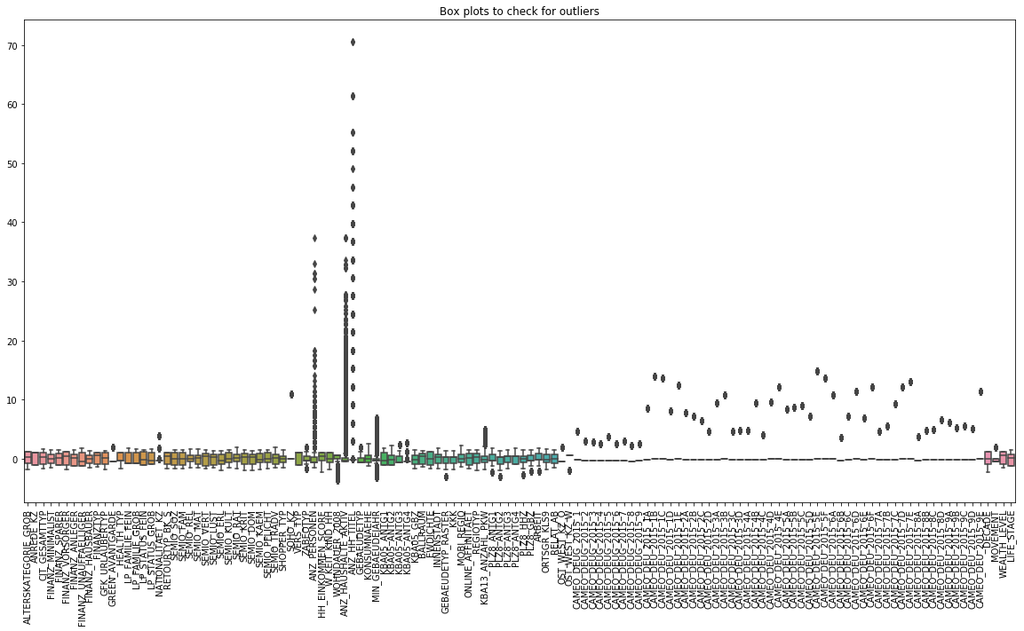

```python
# Box plots to check for outliers
plt.figure(figsize=(20, 10))
sns.boxplot(data=azdias_cleaned_imputed_scaled)
plt.xticks(rotation=90)
plt.title('Box plots to check for outliers')
plt.show()
```

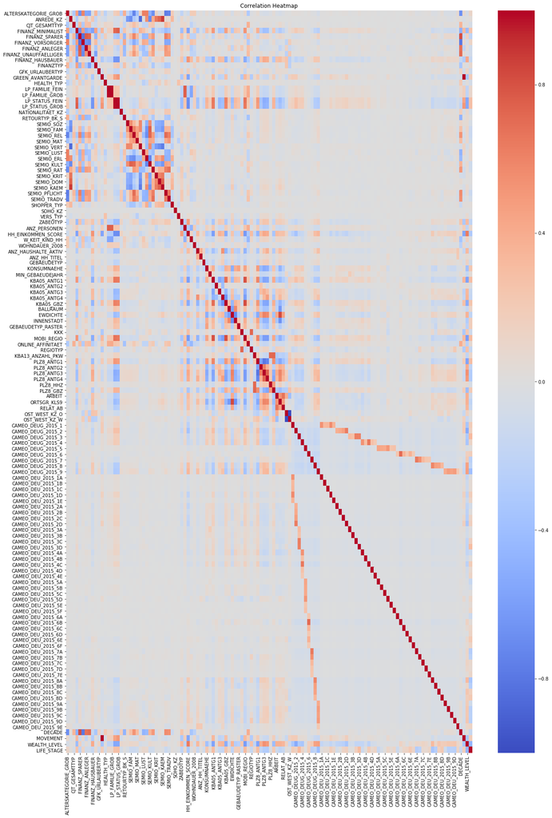

```python
# Heatmap of the correlation matrix
plt.figure(figsize=(20, 30))
sns.heatmap(azdias_cleaned_imputed_scaled.corr(), annot=False, cmap='coolwarm', center=0)
plt.title('Correlation Heatmap')
plt.show()
```

```python
def check_nan_values(df: pd.DataFrame) -> None:
    """
    Check and print the number of NaN values in each column of the dataframe.

    Parameters:
    - df (pd.DataFrame): The dataframe to check for NaN values.

    Returns:
    - None: This function prints the number of NaN values per column.
    """
    nan_counts = df.isnull().sum()
    if nan_counts.sum() == 0:
        print("No NaN values found in the dataframe.")
    else:
        print("Number of NaN values per column:\n", nan_counts)
```

```python
# Use the functions to check the df_scaled dataframe
check_nan_values(azdias_cleaned_imputed_scaled)
```

```
No NaN values found in the dataframe.
```

```python
def check_single_column_scaling(df: pd.DataFrame, column: str, tolerance: float = 1e-6) -> str:
    """
    Check whether the specified column in the dataframe is scaled
    (mean close to 0 and standard deviation close to 1).

    Parameters:
    - df (pd.DataFrame): The dataframe to check for scaling.
    - column (str): The column name to check.
    - tolerance (float): The tolerance level for checking mean and standard deviation. Default is 1e-6.

    Returns:
    - str: A message indicating if the column is properly scaled or not.
    """
    mean = df[column].mean()
    std_dev = df[column].std()

    if abs(mean) > tolerance or abs(std_dev - 1) > tolerance:
        return f"Column '{column}': Scaling check FAILED (Mean: {mean:.4f}, Std Dev: {std_dev:.4f})"
    else:
        return f"Column '{column}': Scaling check PASSED"
```

```python
print(f"Checking whether all columns in the dataframe are scaled:\n")

# Iterate over columns and print the result
for col in azdias_cleaned_imputed_scaled.columns:
    print(check_single_column_scaling(azdias_cleaned_imputed_scaled, col))
```

```
Checking whether all columns in the dataframe are scaled:

Column 'ALTERSKATEGORIE_GROB': Scaling check PASSED
Column 'ANREDE_KZ': Scaling check PASSED
Column 'CJT_GESAMTTYP': Scaling check PASSED
Column 'FINANZ_MINIMALIST': Scaling check PASSED
Column 'FINANZ_SPARER': Scaling check PASSED
Column 'FINANZ_VORSORGER': Scaling check PASSED
Column 'FINANZ_ANLEGER': Scaling check PASSED
Column 'FINANZ_UNAUFFAELLIGER': Scaling check PASSED
Column 'FINANZ_HAUSBAUER': Scaling check PASSED
Column 'FINANZTYP': Scaling check PASSED
Column 'GFK_URLAUBERTYP': Scaling check PASSED
Column 'GREEN_AVANTGARDE': Scaling check PASSED
Column 'HEALTH_TYP': Scaling check PASSED
Column 'LP_FAMILIE_FEIN': Scaling check PASSED
Column 'LP_FAMILIE_GROB': Scaling check PASSED
Column 'LP_STATUS_FEIN': Scaling check PASSED
Column 'LP_STATUS_GROB': Scaling check PASSED
Column 'NATIONALITAET_KZ': Scaling check PASSED
Column 'RETOURTYP_BK_S': Scaling check PASSED
Column 'SEMIO_SOZ': Scaling check PASSED
Column 'SEMIO_FAM': Scaling check PASSED
Column 'SEMIO_REL': Scaling check PASSED
Column 'SEMIO_MAT': Scaling check PASSED
Column 'SEMIO_VERT': Scaling check PASSED
Column 'SEMIO_LUST': Scaling check PASSED
Column 'SEMIO_ERL': Scaling check PASSED
Column 'SEMIO_KULT': Scaling check PASSED
Column 'SEMIO_RAT': Scaling check PASSED
Column 'SEMIO_KRIT': Scaling check PASSED
Column 'SEMIO_DOM': Scaling check PASSED
Column 'SEMIO_KAEM': Scaling check PASSED
Column 'SEMIO_PFLICHT': Scaling check PASSED
Column 'SEMIO_TRADV': Scaling check PASSED
Column 'SHOPPER_TYP': Scaling check PASSED
Column 'SOHO_KZ': Scaling check PASSED
Column 'VERS_TYP': Scaling check PASSED
Column 'ZABEOTYP': Scaling check PASSED
Column 'ANZ_PERSONEN': Scaling check PASSED
```

[output cut: 75 more lines]

```
Column 'CAMEO_DEU_2015_7D': Scaling check PASSED
Column 'CAMEO_DEU_2015_7E': Scaling check PASSED
Column 'CAMEO_DEU_2015_8A': Scaling check PASSED
Column 'CAMEO_DEU_2015_8B': Scaling check PASSED
Column 'CAMEO_DEU_2015_8C': Scaling check PASSED
Column 'CAMEO_DEU_2015_8D': Scaling check PASSED
Column 'CAMEO_DEU_2015_9A': Scaling check PASSED
Column 'CAMEO_DEU_2015_9B': Scaling check PASSED
Column 'CAMEO_DEU_2015_9C': Scaling check PASSED
Column 'CAMEO_DEU_2015_9D': Scaling check PASSED
Column 'CAMEO_DEU_2015_9E': Scaling check PASSED
Column 'DECADE': Scaling check PASSED
Column 'MOVEMENT': Scaling check PASSED
Column 'WEALTH_LEVEL': Scaling check PASSED
Column 'LIFE_STAGE': Scaling check PASSED
```

### Discussion 2.1: Apply Feature Scaling

**My personal Recap**

In order to impute missing values there exist several methods. Some are more sophisticated, as stated, but here an update of sklearn would have been necessary. With the out-of-the-box version I could only use the Imputer() class to fill the NaNs and then use StandardScaler to scale the features to mean=0 and std=1.

Some short checks showed that everything worked fine.

### Step 2.2: Perform Dimensionality Reduction

On your scaled data, you are now ready to apply dimensionality reduction techniques.

- Use sklearn's [PCA](http://scikit-learn.org/stable/modules/generated/sklearn.decomposition.PCA.html) class to apply principal component analysis on the data, thus finding the vectors of maximal variance in the data. To start, you should not set any parameters (so all components are computed) or set a number of components that is at least half the number of features (so there's enough features to see the general trend in variability).
- Check out the ratio of variance explained by each principal component as well as the cumulative variance explained. Try plotting the cumulative or sequential values using matplotlib's [`plot()`](https://matplotlib.org/api/_as_gen/matplotlib.pyplot.plot.html) function. Based on what you find, select a value for the number of transformed features you'll retain for the clustering part of the project.
- Once you've made a choice for the number of components to keep, make sure you re-fit a PCA instance to perform the decided-on transformation.

```python
# Apply PCA to the data.

def apply_pca(data: pd.DataFrame, n_components: int = None) -> PCA:
    """
    Apply PCA to the data.

    Parameters:
    - data: The dataframe to which PCA is to be applied.
    - n_components: Number of components for PCA. If None, all components are computed.

    Returns:
    - pca: Fitted PCA object.
    """
    pca = PCA(n_components=n_components)
    pca.fit(data)
    return pca
```

```python
#pca_all = apply_pca(azdias_cleaned_imputed_scaled)
```

**NOTE:**

Actually I would have taken the function above for calculating the PCA. But I had massive problems in that my Jupyter notebook always crashed when running this function. I lost connection to the Jupyter kernel, which may indicate memory problems.

So I decided to switch to **IncrementalPCA** (see below), because here I can process the dataframe in batches. This worked for me, so I'll keep this solution here.

Also, I only called .fit(), not .fit_transform(), as I shall select an appropriate number of components at first before really transforming the data. This will be done after the selection of the number of components.

```python
from sklearn.decomposition import IncrementalPCA

def apply_incremental_pca(data: pd.DataFrame, n_components: int = None, batch_size: int = None) -> IncrementalPCA:
    """
    Apply IncrementalPCA to the data in batches.

    Parameters:
    - data: The dataframe to which PCA is to be applied.
    - n_components: Number of components for PCA. If None, all components are computed.
    - batch_size: Size of mini-batches for incremental PCA. If None, the whole data is used.

    Returns:
    - ipca: Fitted IncrementalPCA object.
    """
    ipca = IncrementalPCA(n_components=n_components)
    num_batches = -(-data.shape[0] // batch_size)  # Calculate the number of batches

    for i, batch in enumerate(np.array_split(data, num_batches)):
        print(f"Batch {i+1} shape: {batch.shape}")
        ipca.partial_fit(batch)

    return ipca
```

```python
batch_size = 100000
```

```python
# Fit IncrementalPCA in batches
pca_all = apply_incremental_pca(azdias_cleaned_imputed_scaled, batch_size=batch_size)
```

```
Batch 1 shape: (96463, 128)
Batch 2 shape: (96463, 128)
Batch 3 shape: (96463, 128)
Batch 4 shape: (96463, 128)
Batch 5 shape: (96463, 128)
Batch 6 shape: (96462, 128)
Batch 7 shape: (96462, 128)
Batch 8 shape: (96462, 128)
```

```python
# Investigate the variance accounted for by each principal component.

def scree_plot(pca: PCA) -> None:
    """
    Plot the variance explained by each component and cumulative variance explained.

    Parameters:
    - pca: Fitted PCA object.
    """
    explained_var = pca.explained_variance_ratio_
    cumulative_var = np.cumsum(explained_var)

    plt.figure(figsize=(15, 10))

    # Plotting individual explained variance
    plt.bar(
        range(len(explained_var)),
        explained_var,
        alpha=0.5,
        label="Individual explained variance"
    )

    # Plotting cumulative explained variance
    plt.plot(
        range(len(cumulative_var)),
        cumulative_var,
        label="Cumulative explained variance"
    )

    # Draw horizontal line at y=85%
    plt.axhline(y=0.85, color="r", linestyle="--")

    # Draw vertical line at the corresponding number of features on the x-axis
    num_components = np.argmax(cumulative_var >= 0.85)
    plt.axvline(
        x=num_components,
        color="g",
        linestyle="--",
        label=f"85% explained variance (n={num_components+1} components)"
    )

    plt.xlabel("Principal Component")
    plt.ylabel("Variance Explained (%)")
    plt.legend()
    plt.show()
```

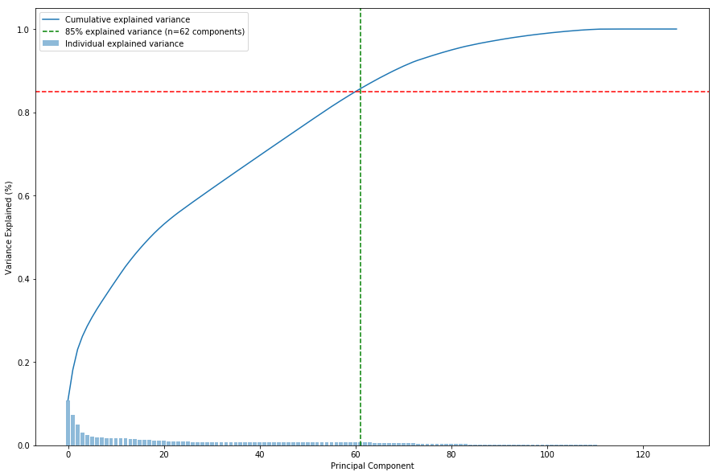

```python
scree_plot(pca_all)
```

```python
# Based on the plot, I decide to take n (as number of components):
n = 62
```

```python
# Re-apply PCA to the data while selecting for number of components to retain.
pca_n = apply_pca(azdias_cleaned_imputed_scaled, n_components=n)
# here it worked without kernel troubles...
```

```python
def transform_data_with_pca(pca: PCA, data: pd.DataFrame) -> np.ndarray:
    """
    Transform the data using a fitted PCA object.

    Parameters:
    - pca: Fitted PCA object.
    - data: The dataframe to be transformed.

    Returns:
    - transformed_data: Data transformed using the fitted PCA.
    """
    return pca.transform(data)
```

```python
# Now I transform the data using the PCA instance with n components
azdias_pca_transformed = transform_data_with_pca(pca_n, azdias_cleaned_imputed_scaled)
```

```python
# Convert the transformed data back to a DataFrame
azdias_pca_transformed_df = pd.DataFrame(
    azdias_pca_transformed,
    columns=[f"PC{i+1}" for i in range(azdias_pca_transformed.shape[1])]
)
```

```python
azdias_pca_transformed_df.shape
```

```
(771701, 62)
```

```python
azdias_pca_transformed_df.head()
```

|  | PC1 | PC2 | PC3 | PC4 | PC5 | PC6 | PC7 | PC8 | PC9 | PC10 | ... | PC53 | PC54 | PC55 | PC56 | PC57 | PC58 | PC59 | PC60 | PC61 | PC62 |
| --- | --- | --- | --- | --- | --- | --- | --- | --- | --- | --- | --- | --- | --- | --- | --- | --- | --- | --- | --- | --- | --- |
| 0 | 4.484911 | -3.100340 | -3.051696 | 0.003710 | -0.608585 | 1.453956 | -0.537710 | 1.163289 | 3.378347 | -1.307242 | ... | 5.353926 | 0.540031 | 2.963472 | 1.594381 | -0.993234 | -0.605293 | -0.456343 | -1.057932 | -0.306796 | -0.204460 |
| 1 | -0.843518 | -0.014114 | -3.529340 | 0.929910 | -2.194858 | -0.242589 | 0.003827 | -0.750841 | -0.570077 | -1.978489 | ... | -0.268554 | -0.688703 | 0.485612 | -0.382902 | 1.846101 | 0.806861 | 0.147130 | 0.901533 | 0.562594 | 0.762877 |
| 2 | -4.739608 | 1.648323 | -0.634713 | -0.403339 | -0.355162 | -0.402177 | 2.239373 | -1.175693 | 0.452899 | 0.788082 | ... | 1.322437 | -0.761245 | 0.069227 | -1.155521 | -1.392065 | -0.167757 | -0.269082 | -0.209068 | -0.064858 | -0.931481 |
| 3 | 0.223153 | 0.034737 | 3.004278 | 0.864008 | 2.277643 | 3.071756 | -3.743679 | -0.027626 | -2.829918 | 0.849350 | ... | 0.089283 | -0.887464 | 0.744094 | 0.062292 | 0.167555 | -0.906099 | 0.713667 | 0.318737 | 0.187916 | -0.746645 |
| 4 | -0.024986 | -0.991223 | -0.760617 | -2.809635 | -2.475288 | 0.099754 | -1.756623 | -0.416006 | 1.628565 | -1.650056 | ... | -0.381165 | 0.417458 | -0.368435 | 0.427037 | -1.055387 | 0.501935 | 0.143601 | -1.707581 | 0.819066 | -1.481699 |

5 rows × 62 columns

### Discussion 2.2: Perform Dimensionality Reduction

**My personal Recap**

As I had troubles with the Jupyter kernel connection I decided to go with IncrementalPCA instead of "normal" PCA. Evaluating the scree plot showed me that for retaining e.g. 85% of the variance in the data I have to keep 62 components. With this reduction of dimensionality "normal" PCA was applicable.

```python
del pca_all, azdias_pca_transformed
```

### Step 2.3: Interpret Principal Components

Now that we have our transformed principal components, it's a nice idea to check out the weight of each variable on the first few components to see if they can be interpreted in some fashion.

As a reminder, each principal component is a unit vector that points in the direction of highest variance (after accounting for the variance captured by earlier principal components). The further a weight is from zero, the more the principal component is in the direction of the corresponding feature. If two features have large weights of the same sign (both positive or both negative), then increases in one tend expect to be associated with increases in the other. To contrast, features with different signs can be expected to show a negative correlation: increases in one variable should result in a decrease in the other.

- To investigate the features, you should map each weight to their corresponding feature name, then sort the features according to weight. The most interesting features for each principal component, then, will be those at the beginning and end of the sorted list. Use the data dictionary document to help you understand these most prominent features, their relationships, and what a positive or negative value on the principal component might indicate.
- You should investigate and interpret feature associations from the first three principal components in this substep. To help facilitate this, you should write a function that you can call at any time to print the sorted list of feature weights, for the *i*-th principal component. This might come in handy in the next step of the project, when you interpret the tendencies of the discovered clusters.

```python
# Map weights for the first principal component to corresponding feature names
# and then print the linked values, sorted by weight.
# HINT: Try defining a function here or in a new cell that you can reuse in the
# other cells.

def pca_weights(pca: PCA, component_num: int, feature_names: List[str]) -> pd.DataFrame:
    """
    Map the weights of the principal components to their corresponding feature names
    and sort them by weight.

    Parameters:
    - pca: Fitted PCA object.
    - component_num: The component number for which the weights are required.
    - feature_names: List of feature names.

    Returns:
    - sorted_weights_df: DataFrame containing features and their corresponding weights, sorted by weight.
    """
    # Get the component weights
    component_weights = pca.components_[component_num]

    # Create a DataFrame for the weights and feature names
    weights_df = pd.DataFrame({
        'Feature': feature_names,
        'Weight': component_weights
    })

    # Sort the DataFrame by weight
    sorted_weights_df = weights_df.sort_values(by='Weight', ascending=False)

    return sorted_weights_df
```

```python
# Example usage for the first principal component
first_component_weights = pca_weights(pca_n, 0, azdias_cleaned_imputed_scaled.columns)
print(first_component_weights)
```

```
                   Feature    Weight
126           WEALTH_LEVEL  0.201371
62              PLZ8_ANTG3  0.197702
38      HH_EINKOMMEN_SCORE  0.196311
63              PLZ8_ANTG4  0.190941
67             ORTSGR_KLS9  0.165793
52                EWDICHTE  0.164056
8         FINANZ_HAUSBAUER  0.159469
49             KBA05_ANTG4  0.136262
61              PLZ8_ANTG2  0.134773
36                ZABEOTYP  0.128333
66                  ARBEIT  0.125874
48             KBA05_ANTG3  0.123885
41     ANZ_HAUSHALTE_AKTIV  0.122428
79       CAMEO_DEUG_2015_9  0.121483
```

[output cut: 114 more lines]

```python
def plot_pca_weights(sorted_weights_df: pd.DataFrame, n: int = 10) -> None:
    """
    Plot the top and bottom n feature weights from a sorted weights DataFrame.

    Parameters:
    - sorted_weights_df: DataFrame containing sorted feature weights.
    - n: Number of top and bottom features to plot. Default is 10.
    """

    # Select top and bottom n features
    top_bottom_n = pd.concat([sorted_weights_df.head(n), sorted_weights_df.tail(n)])

    # Plot
    plt.figure(figsize=(10, 8))
    sns.barplot(x='Weight', y='Feature', data=top_bottom_n, palette="coolwarm")
    plt.title(f"Top and Bottom {n} Feature Weights")
    plt.show()
```

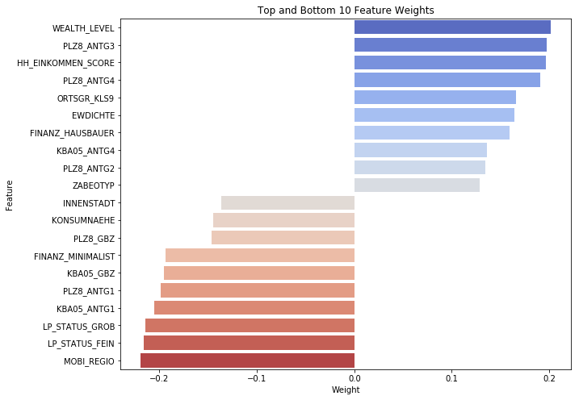

```python
# Example usage for the first principal component
plot_pca_weights(first_component_weights, n=10)
```

```python
# Map weights for the second principal component to corresponding feature names
# and then print the linked values, sorted by weight.
second_component_weights = pca_weights(pca_n, 1, azdias_cleaned_imputed_scaled.columns)
print(second_component_weights)
```

```
                   Feature    Weight
0     ALTERSKATEGORIE_GROB  0.264065
5         FINANZ_VORSORGER  0.235784
25               SEMIO_ERL  0.222403
24              SEMIO_LUST  0.183988
18          RETOURTYP_BK_S  0.163022
39          W_KEIT_KIND_HH  0.119936
9                FINANZTYP  0.116761
28              SEMIO_KRIT  0.102354
33             SHOPPER_TYP  0.101254
3        FINANZ_MINIMALIST  0.095296
8         FINANZ_HAUSBAUER  0.090350
30              SEMIO_KAEM  0.089556
1                ANREDE_KZ  0.071986
62              PLZ8_ANTG3  0.062786
```

[output cut: 114 more lines]

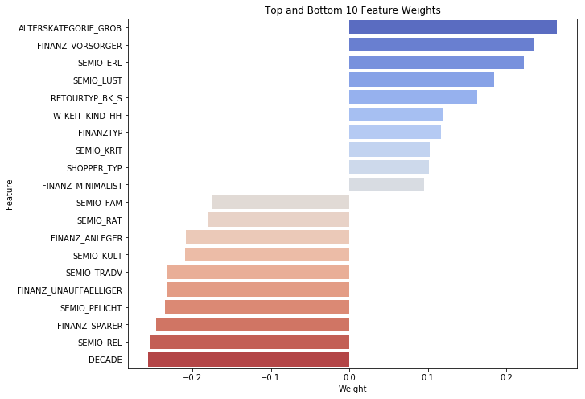

```python
plot_pca_weights(second_component_weights, n=10)
```

```python
# Map weights for the third principal component to corresponding feature names
# and then print the linked values, sorted by weight.
third_component_weights = pca_weights(pca_n, 2, azdias_cleaned_imputed_scaled.columns)
print(third_component_weights)
```

```
                   Feature    Weight
23              SEMIO_VERT  0.338246
19               SEMIO_SOZ  0.261473
20               SEMIO_FAM  0.255197
26              SEMIO_KULT  0.242144
3        FINANZ_MINIMALIST  0.150112
9                FINANZTYP  0.115252
18          RETOURTYP_BK_S  0.098185
21               SEMIO_REL  0.086236
39          W_KEIT_KIND_HH  0.085549
5         FINANZ_VORSORGER  0.081181
22               SEMIO_MAT  0.064692
0     ALTERSKATEGORIE_GROB  0.059005
24              SEMIO_LUST  0.048996
11        GREEN_AVANTGARDE  0.047000
```

[output cut: 114 more lines]

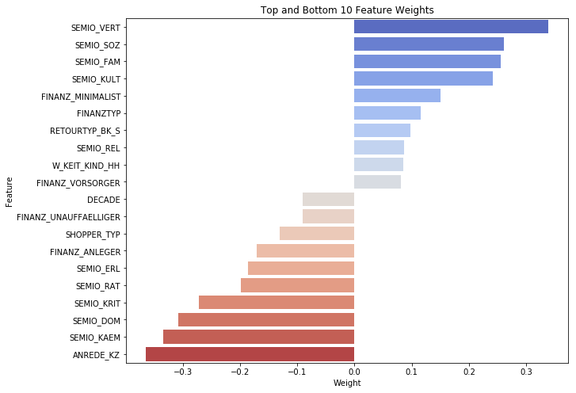

```python
plot_pca_weights(third_component_weights, n=10)
```